# 02 线性回归(二)

2025-9-15

课程代码均在如下 GitHub 仓库开源：https://github.com/GHe0000/xmu_machine_learning

项目自动生成网页地址：https://ghe0000.github.io/xmu_machine_learning

## 目录

- 作业要求
- 背景补充
  - Onehot 编码
  - Early Stop
- 数据预处理，数据集划分
  - 计算准备
  - 数据集载入和检查
  - 按排名可视化价格
  - 数据划分
  - 缺失值补全
  - 文本数据处理
- 模型构建和损失函数定义
  - 特征选取和数据矩阵构建
  - 特征标准化
  - 模型评估和损失函数定义
- 模型训练
  - 梯度下降实现
  - 模型训练，损失函数，评估函数随训练轮数变化
  - 模型评估和预测残差分析
  - Early Stop，自动确定 Epoch
- 超参调优
  - 学习率与 Epoch 与最优 MSE
  - L2 系数与最优 MSE
  - 最优超参
- 不同数据预处理方法下模型对比
  - 自动确定最优 L2 系数
  - 缺失值处理方法对比
  - 文本编码方式对比
  - 人工构造特征对比
  - 最优处理方法
- 权重分析
- 结论
- 参考资料以及 AI 使用说明
- 致谢
- 附一：问题
- 附二：学习心得

## 作业要求

- 学习使用 pandas 库进行数据库操作。(本次 PPT 中有一个例子可供参考)
- 利用加州房价数据集（California Housing Dataset）做线性回归练习。数据文件(housing.csv)可以从附件中下载。该数据集一共有 20640 个样本（行）10 列。以 `median_house_value` 列为样本的 $y$ 值，即预测目标。以其他列为特征（即样本矩阵中 $X$ 的中的列）注意，最后一列 `ocean_proximity` 是字符串，请思考如何将其化为数值，若不知如何操作，也可以弃之不用。
- 用梯度下降法+L2 正则化训练。机器学习流程要完整，训练过程和调优过程清晰。
- 作业要有完整的结构

## 背景补充

### Onehot 编码

对于类别型数据, 如果不同类别之间不存在明确的大小关系, 就不能简单地将其编码为 $0,1,2,\cdots$. 如果直接赋予不同数值, 就会人为引入类别之间的顺序和距离关系.

因此可以使用 Onehot 编码. 假设一个特征一共有 $k$ 个类别

$$ C=\{c_1,c_2,\cdots,c_k\}, $$

则可以将第 $i$ 个类别表示为第 $i$ 个位置为 $1$, 其余位置均为 $0$ 的向量

$$ c_i\rightarrow(0,\cdots,0,1,0,\cdots,0). $$

这样不同类别被看作相互独立的离散特征, 不会人为引入类别之间的大小关系.

但是当线性模型中同时包含常数项时, 如果完整保留 $k$ 个 Onehot 特征, 则每个样本均满足

$$ x_1+x_2+\cdots+x_k=1. $$

而数据矩阵中常数列本身也是 $1$, 因此这些特征之间存在严格的线性相关关系. 为了避免这种情况, 一般选取其中一个类别作为基准组, 删除其对应的 Onehot 特征, 最终只保留 $k-1$ 个特征. 基准组可以看作全部 Onehot 分量均为 $0$, 其余类别的模型参数表示相对于基准组的差异.

### Early Stop

梯度下降训练过程中需要人为指定训练轮数 Epoch. 如果 Epoch 太小, 模型可能还没有充分收敛. 如果 Epoch 太大, 则模型收敛后还会继续进行大量无意义的计算, 并且可能出现过拟合.

因此可以使用 Early Stop 自动确定停止训练的位置. 其基本思想是使用验证集误差监控模型训练过程. 记第 $t$ 个 Epoch 的验证集误差为

$$ J_{\mathrm{val}}^{(t)}, $$

训练过程中记录目前得到的最小验证集误差 $J_{\mathrm{best}}$. 当新的验证集误差相比当前最优结果有足够明显的下降时, 更新最优模型参数. 如果连续若干个 Epoch 验证集误差均没有明显改善, 则认为模型已经基本收敛并停止训练.

通常引入两个参数

- `patience`: 允许验证集误差连续多少轮没有明显改善.
- `min_delta`: 判断一次误差下降是否足够明显的阈值.

这样可以在不提前确定精确 Epoch 的情况下自动确定训练轮数.

## 数据预处理，数据集划分

### 计算准备

导入需要的库，并对 Jupyter Notebook 做初始化工作.

```python
import numpy as np # 数值计算库
import numba as nb # 引入 jit 来加速函数（如果需要）
import sympy as sym # 符号计算库
import matplotlib as mpl
import matplotlib.pyplot as plt # 图像绘制
from matplotlib.backends.backend_agg import FigureCanvasAgg # 设置图像后端用
import ipywidgets as ipw # 交互控件
from IPython.display import display, Math, Latex # 打印数学公式
import time
import tracemalloc

import pandas as pd

from io import BytesIO
import matplotlib.animation as animation # 创建动画
from IPython.display import HTML # 动画嵌入
import scipy

# 使用 mathjax 来在 jupyter notebook 显示数学公式
sym.init_printing(use_latex='mathjax')

# 设置 matplotlib 绘制的图像嵌入到 jupyter notebook 的方式
%matplotlib widget

# 一个工具函数，可以让静态图片不经过 widget 直接嵌入 Jupyter notebook
# 这样图片可以直接存到 nb 文件里，而不是需要运行才能显示（类似 inline）
def display_inline(fig):
    try:
        for i in range(2):
            try:
                fig.set_canvas(FigureCanvasAgg(fig))
                fig.tight_layout()
                fig.canvas.draw()
                display(fig)
                return
            except Exception:
                if i == 1: raise
    finally:
        plt.close(fig) # 释放 fig，减小资源消耗

# 一个工具函数，用于在 Jupyter 中快速实现公式和字符串混合输出
def display_math(*args):
    parts = []
    for a in args:
        if isinstance(a, str):
            parts.append(a)
        else:
            parts.append(sym.latex(a))
    display(Math("".join(parts)))

# 设置 matplotlib 使用的字体，避免出现中文问题
plt.rcParams.update({
    # 字体
    "font.family": ["SimSun", "Times New Roman"],
    "font.size": 14,
    "mathtext.fontset": "cm",
    "axes.unicode_minus": False,

    # 字号
    "axes.titlesize": 14,
    "axes.labelsize": 14,
    "xtick.labelsize": 14,
    "ytick.labelsize": 14,
    "legend.fontsize": 14,
    "figure.titlesize": 14,
})

# 设置种子，保证可重复性
np.random.seed(3407)
```

### 数据集载入和检查

根据要求，我们先载入 `housing.csv` 数据集，并观察数据集中前几组数据，得到数据集结构.

```python
df = pd.read_csv("housing.csv")
df.head(5)
```

|  | longitude | latitude | housing_median_age | total_rooms | total_bedrooms | population | households | median_income | median_house_value | ocean_proximity |
| --- | --- | --- | --- | --- | --- | --- | --- | --- | --- | --- |
| 0 | -122.23 | 37.88 | 41.0 | 880.0 | 129.0 | 322.0 | 126.0 | 8.3252 | 452600.0 | NEAR BAY |
| 1 | -122.22 | 37.86 | 21.0 | 7099.0 | 1106.0 | 2401.0 | 1138.0 | 8.3014 | 358500.0 | NEAR BAY |
| 2 | -122.24 | 37.85 | 52.0 | 1467.0 | 190.0 | 496.0 | 177.0 | 7.2574 | 352100.0 | NEAR BAY |
| 3 | -122.25 | 37.85 | 52.0 | 1274.0 | 235.0 | 558.0 | 219.0 | 5.6431 | 341300.0 | NEAR BAY |
| 4 | -122.25 | 37.85 | 52.0 | 1627.0 | 280.0 | 565.0 | 259.0 | 3.8462 | 342200.0 | NEAR BAY |

根据要求，`median_house_value` 作为我们模型的预测值，其余列作为模型的输入.

检查一下数据的类型和基本特征：

```python
df.info()
df.describe()
```

```
<class 'pandas.DataFrame'>
RangeIndex: 20640 entries, 0 to 20639
Data columns (total 10 columns):
 #   Column              Non-Null Count  Dtype
---  ------              --------------  -----
 0   longitude           20640 non-null  float64
 1   latitude            20640 non-null  float64
 2   housing_median_age  20640 non-null  float64
 3   total_rooms         20640 non-null  float64
 4   total_bedrooms      20433 non-null  float64
 5   population          20640 non-null  float64
 6   households          20640 non-null  float64
 7   median_income       20640 non-null  float64
 8   median_house_value  20640 non-null  float64
 9   ocean_proximity     20640 non-null  str
dtypes: float64(9), str(1)
memory usage: 1.6 MB
```

|  | longitude | latitude | housing_median_age | total_rooms | total_bedrooms | population | households | median_income | median_house_value |
| --- | --- | --- | --- | --- | --- | --- | --- | --- | --- |
| count | 20640.000000 | 20640.000000 | 20640.000000 | 20640.000000 | 20433.000000 | 20640.000000 | 20640.000000 | 20640.000000 | 20640.000000 |
| mean | -119.569704 | 35.631861 | 28.639486 | 2635.763081 | 537.870553 | 1425.476744 | 499.539680 | 3.870671 | 206855.816909 |
| std | 2.003532 | 2.135952 | 12.585558 | 2181.615252 | 421.385070 | 1132.462122 | 382.329753 | 1.899822 | 115395.615874 |
| min | -124.350000 | 32.540000 | 1.000000 | 2.000000 | 1.000000 | 3.000000 | 1.000000 | 0.499900 | 14999.000000 |
| 25% | -121.800000 | 33.930000 | 18.000000 | 1447.750000 | 296.000000 | 787.000000 | 280.000000 | 2.563400 | 119600.000000 |
| 50% | -118.490000 | 34.260000 | 29.000000 | 2127.000000 | 435.000000 | 1166.000000 | 409.000000 | 3.534800 | 179700.000000 |
| 75% | -118.010000 | 37.710000 | 37.000000 | 3148.000000 | 647.000000 | 1725.000000 | 605.000000 | 4.743250 | 264725.000000 |
| max | -114.310000 | 41.950000 | 52.000000 | 39320.000000 | 6445.000000 | 35682.000000 | 6082.000000 | 15.000100 | 500001.000000 |

其中 `ocean_proximity` 是一个字符串类型，需要进行特殊处理才能进入之后的模型. 在之后我们会进行讨论和分析.

虽然对于这个数据集大概率没有缺值（类似 Kaggle Titanic 数据集那样可能会有缺值的情况）. 但为了保险起见，我们还是检查一下：

```python
print(df.isnull().sum())
```

```
longitude               0
latitude                0
housing_median_age      0
total_rooms             0
total_bedrooms        207
population              0
households              0
median_income           0
median_house_value      0
ocean_proximity         0
dtype: int64
```

看来，数据集不是很完善，`total_bedroom` 出现了缺值，我们查看一下缺值的行的占比：

```python
print("全部数据集数据数：")
print(df.shape[0])
print("存在缺失值的数据数：")
print(df.isnull().any(axis=1).sum())
print("存在缺失值的数据占比：")
print(df.isnull().any(axis=1).mean())
```

```
全部数据集数据数：
20640
存在缺失值的数据数：
207
存在缺失值的数据占比：
0.01002906976744186
```

好在，数据集中存在缺失值的数据只有 $1\%$ 左右，缺失的数据量不大. 这里我们有两种做法：1. 直接删去缺失的数据集 2. 用某种方式补充缺失的数据. 这里为了能更全面地利用数据，这里我们采取方案 $2$，因此之后我们需要用某种方法来补全缺失的参数.

### 按排名可视化价格

我们对数据集中的价格进行排序，按排名绘制价格，显示价格大体的数据分布

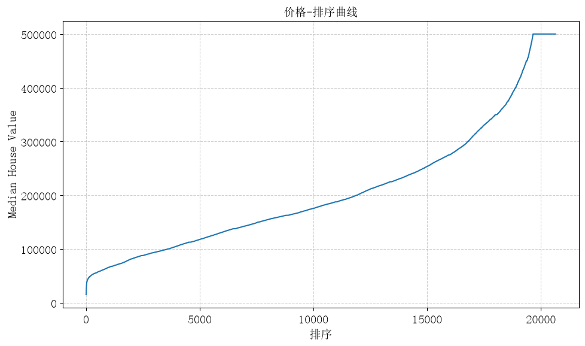

```python
df_plot = df.copy()
df_plot = df_plot.sort_values(by="median_house_value", ascending=True).reset_index(drop=True)
df_plot["rank"] = df_plot.index + 1

df_plot["percentile"] = df_plot["rank"] / len(df_plot)
fig, ax = plt.subplots(figsize=(10, 6))

ax.plot(df_plot["rank"], df_plot["median_house_value"])

ax.set_title("价格-排序曲线")
ax.set_xlabel("排序")
ax.set_ylabel("Median House Value")
ax.grid(True, linestyle="--", alpha=0.6)
display_inline(fig)
```

这里价格在 $5\times10^5$ 上似乎存在一个“截断”，这种截断是不自然的，可能对我们的模型存在影响.

### 数据划分

在进行所有的数据处理之前，我们先进行数据划分，防止出现信息泄漏. 数据集划分成三份，分别是训练集，验证集，测试集. 三个集合的占比定为 $8:1:1$

这里由于存在缺失值的数据之后需要进行补全，为了防止我们人为补全对测试和验证的影响，我们人为将所有的存在缺失值的数据放入训练集中.

```python
N = len(df)
n_train = int(N * 0.8)
n_val = int(N * 0.1)
n_test = N - n_train - n_val

df_miss_mask = df.isnull().any(axis=1)
df_miss = df.loc[df_miss_mask].copy()
df_nomiss = df.loc[~df_miss_mask].copy()
n_train_nomiss = n_train - len(df_miss)

df_nomiss = df_nomiss.sample(frac=1, random_state=3407).copy()

train_nomiss = df_nomiss.iloc[:n_train_nomiss].copy()

val_df = df_nomiss.iloc[n_train_nomiss:n_train_nomiss + n_val].copy()
test_df = df_nomiss.iloc[n_train_nomiss + n_val:].copy()
train_df = pd.concat([df_miss, train_nomiss], axis=0).copy()

train_df = train_df.reset_index(drop=True)
val_df   = val_df.reset_index(drop=True)
test_df  = test_df.reset_index(drop=True)
```

检查一下三个集合的尺寸和是否存在缺失值

```python
print(f"训练集：形状{train_df.shape}，缺失值数量：{train_df.isnull().sum().sum()}")
print(f"验证集：形状{val_df.shape}，缺失值数量：{val_df.isnull().sum().sum()}")
print(f"测试集：形状{test_df.shape}，缺失值数量：{test_df.isnull().sum().sum()}")
```

```
训练集：形状(16512, 10)，缺失值数量：207
验证集：形状(2064, 10)，缺失值数量：0
测试集：形状(2064, 10)，缺失值数量：0
```

三个集合的大小和缺失值数量与我们的预期相同，后续训练我们均使用此数据集.

### 缺失值补全

现在训练集存在缺失值，我们先观察存在缺失值的列 `total_bedrooms` 的数据分布.

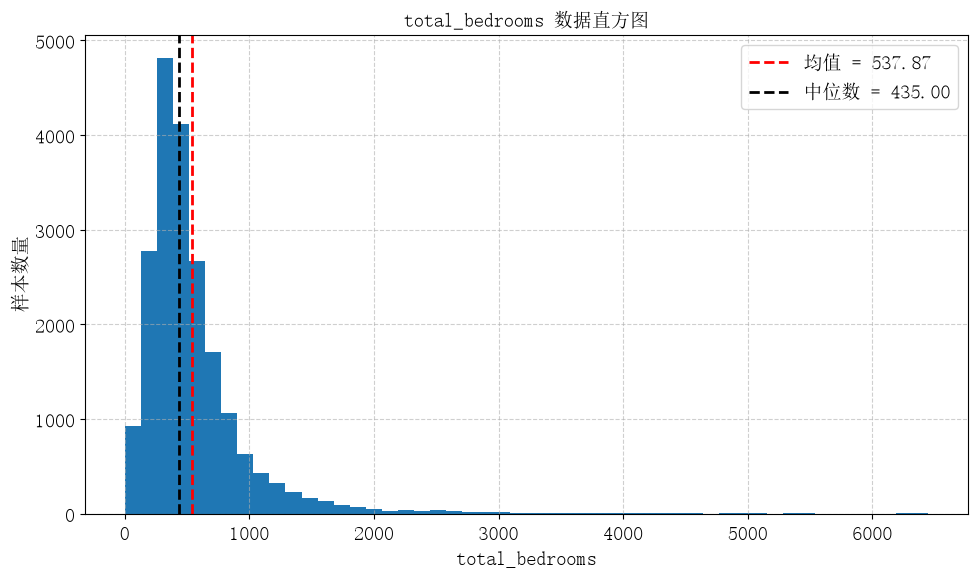

```python
fig, ax = plt.subplots(figsize=(10, 6))

ax.hist(
    df["total_bedrooms"].dropna(),
    bins=50
)

ax.axvline(
    df["total_bedrooms"].dropna().mean(),
    linestyle="--",
    linewidth=2,
    color="r",
    label=f"均值 = {df["total_bedrooms"].dropna().mean():.2f}"
)

ax.axvline(
    df["total_bedrooms"].dropna().median(),
    linestyle="--",
    linewidth=2,
    color="k",
    label=f"中位数 = {df["total_bedrooms"].dropna().median():.2f}"
)

ax.grid(True, linestyle="--", alpha=0.6)
ax.set_title("total_bedrooms 数据直方图")
ax.set_xlabel("total_bedrooms")
ax.set_ylabel("样本数量")
ax.legend()
display_inline(fig)
```

可见，这里 `total_bedrooms` 这列数据是某个长尾分布，从图中我们可以看见，中位数相比于均值更接近我们概率分布的最概然值（这里不用众数是因为众数依赖于分箱），对于缺失值，由于我们没有什么更多的信息，这里我们选取**中位数**作为缺失值进行填充.

```python
train_df["total_bedrooms"] = train_df["total_bedrooms"].fillna(train_df["total_bedrooms"].median())
```

经过填补后，验证确实没有了缺失值：

```python
print(f"训练集：形状{train_df.shape}，缺失值数量：{train_df.isnull().sum().sum()}")
```

```
训练集：形状(16512, 10)，缺失值数量：0
```

严格来说，缺失值会和其他列的值有关，因此缺失值的补充本质上也是一个机器学习问题，同样可以建立一个机器学习模型从其他列推断当前列的值，这里由于此操作比较繁琐，且缺失值数量较少，同时无论用什么方式都是某种推测，存在误差，因此我们直接选取中位数进行填补并不会造成太大问题. 当然，后续可以考虑分析不同填补方式对模型准确度的影响.

### 文本数据处理

前面我们发现，`ocean_proximity` 是一个字符串类型，我们先检查这一列有几种字符串：

```python
df["ocean_proximity"].value_counts()
```

```
ocean_proximity
<1H OCEAN     9136
INLAND        6551
NEAR OCEAN    2658
NEAR BAY      2290
ISLAND           5
Name: count, dtype: int64
```

这里一共有 $5$ 种类别，这里我们需要给标签赋予特征数值. 虽然这里大体上可以按照靠近海洋的距离进行某种排序，但是注意到 `NEAR OCEAN` 和 `NEAR BAY` 其实是并列的，因此严格起见，我们还是将所有的特征作为并列的特征进行处理，因此我们无法对这几个特征进行排序，要将其赋予某种特征数值，这里我们选取 Onehot 编码.

所谓 Onehot 编码，在这里就是新增五个特征值，假如是 `<1H OCEAN` 则对应 $(1,0,0,0,0)$，假如是 `INLAND` 则对应 $(0,1,0,0,0)$，其余同理. 进行这种编码处理后，数据集处理如下：

```python
ocean_categories = [
    "<1H OCEAN",
    "INLAND",
    "ISLAND",
    "NEAR BAY",
    "NEAR OCEAN"
]

def encode_ocean_proximity(data):
    data = data.copy()
    data["ocean_proximity"] = pd.Categorical(
        data["ocean_proximity"],
        categories=ocean_categories
    )
    data = pd.get_dummies(
        data,
        columns=["ocean_proximity"],
        drop_first=False,
        dtype=float
    )
    return data

train_df = encode_ocean_proximity(train_df)
val_df   = encode_ocean_proximity(val_df)
test_df  = encode_ocean_proximity(test_df)
```

检查一下前几个数据的最后五列：

```python
train_df.iloc[:5,-5:]
```

|  | ocean_proximity_<1H OCEAN | ocean_proximity_INLAND | ocean_proximity_ISLAND | ocean_proximity_NEAR BAY | ocean_proximity_NEAR OCEAN |
| --- | --- | --- | --- | --- | --- |
| 0 | 0.0 | 0.0 | 0.0 | 1.0 | 0.0 |
| 1 | 0.0 | 0.0 | 0.0 | 1.0 | 0.0 |
| 2 | 0.0 | 0.0 | 0.0 | 1.0 | 0.0 |
| 3 | 0.0 | 0.0 | 0.0 | 1.0 | 0.0 |
| 4 | 0.0 | 0.0 | 0.0 | 1.0 | 0.0 |

与我们的预期相同.

此时模型输入的特征一共有：

```python
print(train_df.shape[1]-1)
```

```
13
```

也就是模型一共有 $13$ 个特征.

## 模型构建和损失函数定义

### 特征选取和数据矩阵构建

由于这次模型特征比较多，因此这里特征选取我们暂时不使用更高阶的特征，先只考虑所有的一阶特征. 也就是模型为： $$ y= \theta_0 + \sum_{k=1}^{13} \theta_i x_i $$

因此，数据矩阵 $X$ 构造为：

$$ X = \begin{bmatrix} 1 & x_1^{(1)} & x_2^{(1)} & \cdots & x_{13}^{(1)} \\ 1 & x_1^{(2)} & x_2^{(2)} & \cdots & x_{13}^{(2)} \\ \vdots & \vdots & \vdots & \ddots & \vdots \\ 1 & x_1^{(n_{train})} & x_2^{(n_{train})} & \cdots & x_{13}^{(n_{train})} \\ \end{bmatrix} $$

其中 $n_{train}$ 为训练的样本量.

```python
def gen_features(df):
    target_col = "median_house_value"
    feature_cols = [col for col in df.columns if col != target_col]
    X = df[feature_cols].to_numpy(dtype=np.float64)
    X = np.column_stack([np.ones(len(df), dtype=np.float64), X])
    y = df[target_col].to_numpy(dtype=np.float64)
    return X, y

X_train, y_train = gen_features(train_df)
X_val, y_val = gen_features(val_df)
```

参数矩阵为： $$ w=\begin{bmatrix} \theta_0 & \theta_1 & \cdots & \theta_{13} \end{bmatrix} $$ 初始时使用正态分布随机数进行初始化.

```python
w = np.random.normal(loc=0.0, scale=1, size=14)
```

### 特征标准化

之后我们需要进行特征规范化，这里我们对特征进行标准化，防止不同特征之间分布差异过大，导致不同特征的梯度差异过大，使得只能训练某几个特定参数

具体而言，特征标准化的操作是：

$$ x^{(i)}_{norm} = \frac{x^{(i)}-\mu}{\sigma} $$ 其中 $x^{(i)}$ 为某个数据特征的第 $i$ 个值，$\mu$ 为对应列的平均值，$\sigma$ 为这一列的标准差.

```python
@nb.njit
def normalize_features(X, mu_train, sigma_train):
    X_norm = X.copy()
    for j in range(1, X.shape[1]):
        if sigma_train[j-1] > 1e-12:
            X_norm[:, j] = (X[:, j] - mu_train[j-1]) / sigma_train[j-1]
        else:
            X_norm[:, j] = X[:, j] - mu_train[j-1]
    return X_norm

mu_train = np.mean(X_train[:, 1:], axis=0)
sigma_train = np.std(X_train[:, 1:], axis=0)

X_train = normalize_features(X_train, mu_train, sigma_train)
X_val = normalize_features(X_val, mu_train, sigma_train)
```

### 模型评估和损失函数定义

模型评估函数取 MSE： $$ J = \frac{1}{n} (y_{pred}-y)^T (y_{pred}-y) $$ MSE 越小，则模型与数据越吻合，我们认为模型的效果越好.

损失函数取 MSE+L2，这里 L2 正则化为了防止出现过拟合： $$ L = \frac{1}{2} J + \frac{\lambda}{2} \sum_{i=1}^{n} \theta^2_i $$ 其中第二项为 L2 正则化项，$\lambda$ 为 L2 正则化系数，是模型的一个超参.

```python
@nb.njit()
def mse_function(y_pred, y):
    m = y.size
    error = y_pred - y
    return (error.T @ error) / m

@nb.njit()
def loss_function(y_pred, y, w, lam=0.1):
    mse_loss = mse_function(y_pred, y)
    l2_loss = 0.5 * (w.T @ w)
    return 0.5 * mse_loss + lam * l2_loss
```

## 模型训练

### 梯度下降实现

根据前面的损失函数定义： $$ L = \frac{1}{2} J + \frac{\lambda}{2} \sum_{i=1}^{n} \theta^2_i $$ 求关于参数 $w$ 的梯度： $$ \nabla_w L = \frac{1}{n} X^T (Xw-y) + \lambda w $$

设学习率为 $\eta>0$，是模型训练过程中的一个超参，$t+1$ 次迭代更新公式为：

$$ w^{(t+1)} = w^{(t)} - \eta \nabla_w L (w^{(t)}) $$

代码实现如下：

```python
@nb.njit()
def gradient(X, y, w, lam):
    grad = X.T @ (X @ w - y) / y.size + lam * w.copy()
    return grad

@nb.njit()
def train_history(X_train, y_train, X_val, y_val, w_init, epochs, lr, lam):
    w = w_init.copy()
    loss_history = np.zeros(epochs + 1)
    train_mse_history = np.zeros(epochs + 1)
    val_mse_history = np.zeros(epochs + 1)
    y_train_pred = X_train @ w
    y_val_pred = X_val @ w
    loss_history[0] = loss_function(y_train_pred, y_train, w, lam)
    train_mse_history[0] = mse_function(y_train_pred, y_train)
    val_mse_history[0] = mse_function(y_val_pred, y_val)
    for epoch in range(1, epochs + 1):
        grad = gradient(X_train, y_train, w, lam)
        w -= lr * grad
        y_train_pred = X_train @ w
        y_val_pred = X_val @ w
        loss_history[epoch] = loss_function(y_train_pred, y_train, w, lam)
        train_mse_history[epoch] = mse_function(y_train_pred, y_train)
        val_mse_history[epoch] = mse_function(y_val_pred, y_val)
    return w, loss_history, train_mse_history, val_mse_history
```

### 模型训练，损失函数，评估函数随训练轮数变化

综上，我们构建了一个机器学习模型，下面我们进行训练，先设定如下超参：

训练，并绘制 MSE 和 Loss 随 Epoch 的变化曲线：

```python
lr = 0.1
lam = 0.1
n_epochs = 1000

t_start = time.time()
print("开始训练...")
w, loss_history, train_mse_history, val_mse_history = train_history(
    X_train, y_train, X_val, y_val, w, n_epochs, lr, lam
)
print(f"结束，耗时{time.time()-t_start:.2f}s")
```

```
开始训练...
结束，耗时6.76s
```

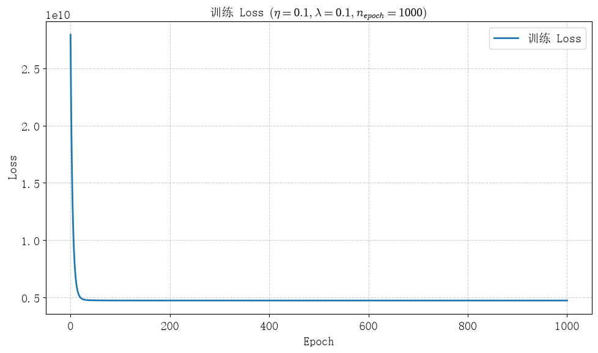

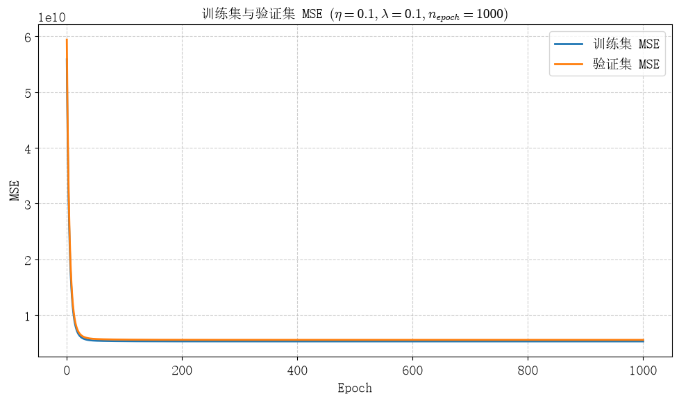

```python
def plot_training_history(loss_history, train_mse_history, val_mse_history, title_suffix=""):
    epochs = np.arange(len(loss_history))
    fig_loss, ax = plt.subplots(figsize=(10, 6))
    ax.plot(epochs, loss_history, linewidth=2, label="训练 Loss")
    ax.set_title("训练 Loss" + title_suffix)
    ax.set_xlabel("Epoch"); ax.set_ylabel("Loss")
    ax.grid(True, linestyle="--", alpha=0.6); ax.legend()
    ax.ticklabel_format(style="sci", axis="y", scilimits=(0, 0))
    fig_mse, ax = plt.subplots(figsize=(10, 6))
    ax.plot(epochs, train_mse_history, linewidth=2, label="训练集 MSE")
    ax.plot(epochs, val_mse_history, linewidth=2, label="验证集 MSE")
    ax.set_title("训练集与验证集 MSE" + title_suffix)
    ax.set_xlabel("Epoch"); ax.set_ylabel("MSE")
    ax.grid(True, linestyle="--", alpha=0.6); ax.legend()
    ax.ticklabel_format(style="sci", axis="y", scilimits=(0, 0))
    return fig_loss, fig_mse

fig_loss, fig_mse = plot_training_history(
    loss_history, train_mse_history, val_mse_history,
    r" $(\eta=0.1,\lambda=0.1,n_{epoch}=1000)$"
)
display_inline(fig_loss)
display_inline(fig_mse)
```

可见，随着我们模型的训练，我们的 Loss 和训练集，验证集的 MSE 均下降. 说明我们的训练是有效的，同时从图中可以看到，这里没有明显的“过学习”的情况.

实际上，这里 Loss 和 MSE 仍旧很大（$\sim10^9$），所以可能是线性模型的表现能力不够，导致的欠学习的情况. 我们先进行模型预测的残差分析看看情况.

### 模型评估和预测残差分析

下面我们来分析模型预测的价格和实际价格的差异. 这里由于自变量很多，因此我们不能像之前简单的一元模型那样，横座标直接取模型输入.

这里图像的横座标取价格的排名. 并绘制真实价格和预测价格随排名的曲线以及残差随排名的曲线.

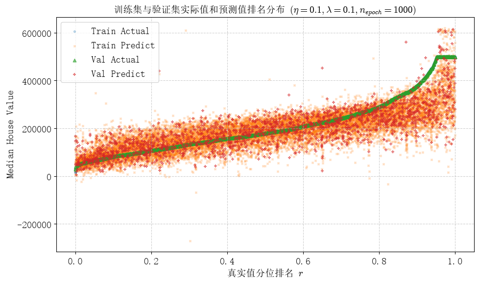

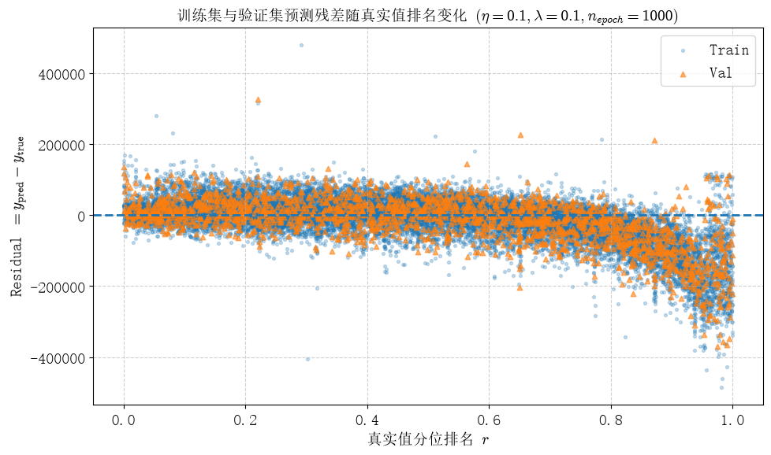

```python
def plot_rank_residual(y_train, y_train_pred, y_val, y_val_pred, title_suffix=""):
    y_true_all = np.concatenate([y_train, y_val]); y_pred_all = np.concatenate([y_train_pred, y_val_pred])
    set_all = np.concatenate([np.zeros(y_train.size, dtype=int), np.ones(y_val.size, dtype=int)])

    idx = np.argsort(y_true_all)
    y_true_sorted = y_true_all[idx]; y_pred_sorted = y_pred_all[idx]; set_sorted = set_all[idx]
    rank = np.linspace(0, 1, y_true_all.size)
    train_mask = set_sorted == 0; val_mask = set_sorted == 1
    residual_sorted = y_pred_sorted - y_true_sorted

    fig_rank, ax = plt.subplots(figsize=(10, 6))
    ax.scatter(rank[train_mask], y_true_sorted[train_mask], marker="o", s=8, alpha=0.25, label="Train Actual")
    ax.scatter(rank[train_mask], y_pred_sorted[train_mask], marker="x", s=8, alpha=0.25, label="Train Predict")
    ax.scatter(rank[val_mask], y_true_sorted[val_mask], marker="^", s=22, alpha=0.6, label="Val Actual")
    ax.scatter(rank[val_mask], y_pred_sorted[val_mask], marker="+", s=22, alpha=0.6, label="Val Predict")
    ax.set_title("训练集与验证集实际值和预测值排名分布" + title_suffix)
    ax.set_xlabel(r"真实值分位排名 $r$"); ax.set_ylabel("Median House Value")
    ax.grid(True, linestyle="--", alpha=0.6); ax.legend()
    fig_residual, ax = plt.subplots(figsize=(10, 6))
    ax.scatter(rank[train_mask], residual_sorted[train_mask], marker="o", s=8, alpha=0.25, label="Train")
    ax.scatter(rank[val_mask], residual_sorted[val_mask], marker="^", s=22, alpha=0.6, label="Val")
    ax.axhline(0, linestyle="--", linewidth=2)
    ax.set_title("训练集与验证集预测残差随真实值排名变化" + title_suffix)
    ax.set_xlabel(r"真实值分位排名 $r$"); ax.set_ylabel(r"Residual $=y_{\mathrm{pred}}-y_{\mathrm{true}}$")
    ax.grid(True, linestyle="--", alpha=0.6); ax.legend()
    return fig_rank, fig_residual

y_train_pred = X_train @ w
y_val_pred = X_val @ w

fig_rank, fig_residual = plot_rank_residual(
    y_train, y_train_pred,
    y_val, y_val_pred,
    r" $(\eta=0.1,\lambda=0.1,n_{epoch}=1000)$"
)

display_inline(fig_rank)
display_inline(fig_residual)
```

从实际值和预测值的排名分布可以看到，模型能够学习房价随真实值排名整体上升的主要趋势，说明当前多元线性回归模型能够提取数据中的主要线性关系.

但是预测值相对于真实值仍存在较大的离散，且这种差异在高房价区域更加明显. 特别是在真实值排名较高的区域，预测结果整体低于真实值，说明模型对于高房价样本存在比较明显的系统性低估.

进一步观察残差分布可以看到，残差并没有随机、均匀地分布在 $0$ 两侧. 随着真实房价排名增加，残差整体逐渐由正值向负值移动，即模型对低房价样本存在一定程度的高估，而对高房价样本存在明显低估. 这说明真实房价与当前输入特征之间并不是简单的一阶线性关系，当前模型仍存在一定的欠拟合.

同时，残差的离散程度随真实房价增加而增大，表现出一定的异方差特征，说明高房价区域本身也具有更大的预测不确定性.

我们也可以用 $R^2$ 来评估模型，$R^2$ 定义为： $$ R^2 = 1 - \frac{\sum_i (y_i - y_{pred,i})^2 }{\sum_i(y_i - \bar{y})^2} $$

当前模型在训练集和验证集上的 $R^2$ 为：

```python
@nb.njit()
def r2_function(y_pred, y):
    ss_res = np.sum((y - y_pred)**2)
    ss_tot = np.sum((y - np.mean(y))**2)
    return 1.0 - ss_res / ss_tot

y_train_pred = X_train @ w
y_val_pred = X_val @ w

train_r2 = r2_function(y_train_pred, y_train)
val_r2 = r2_function(y_val_pred, y_val)

print(f"训练集 R^2：{train_r2:.6f}")
print(f"验证集 R^2：{val_r2:.6f}")
```

```
训练集 R^2：0.602602
验证集 R^2：0.609788
```

这表示当前线性模型解释了约 60% 的的数据变异性.

### Early Stop，自动确定 Epoch

前面的训练过程中，我们人为指定训练轮数 $n_{epoch}$，但是实际上模型需要多少轮才能收敛并不能提前确定. 如果训练轮数太少，模型可能还没有充分收敛；如果训练轮数过大，则会进行大量无意义的重复计算，并且可能使模型出现过拟合.

因此，我们使用验证集 MSE 对模型训练过程进行监控. 当验证集 MSE 连续若干轮没有明显下降时，认为模型已经基本收敛，停止训练，并取验证集 MSE 最小时对应的参数作为最终参数.

这里引入两个参数：

- `patience`：允许验证集 MSE 连续多少轮没有改善.
- `min_delta`：认为 MSE 发生有效改善所需要达到的最小相对变化量.

我们取 `patience`=500, `min_delta`=$10^{-5}$.

```python
@nb.njit()
def build_quadratic_terms(X, y):
    A = X.T @ X / y.size
    b = X.T @ y / y.size
    c = (y.T @ y) / y.size
    return A, b, c

@nb.njit()
def mse_from_terms(w, A, b, c):
    mse = w.T @ (A @ w) - 2.0*(w.T @ b) + c
    return max(mse, 0.0)

@nb.njit()
def train_early_stop_history(X_train, y_train, X_val, y_val,
                             w_init, max_epochs, lr, lam, patience=500, min_delta=1e-5):
    A_train, b_train, c_train = build_quadratic_terms(X_train, y_train)
    A_val, b_val, c_val = build_quadratic_terms(X_val, y_val)
    w = w_init.copy()
    best_w = w.copy()
    loss_history = np.zeros(max_epochs + 1)
    train_mse_history = np.zeros(max_epochs + 1)
    val_mse_history = np.zeros(max_epochs + 1)
    best_val = mse_from_terms(w, A_val, b_val, c_val)
    best_epoch = 0; wait = 0; last_epoch = 0

    train_mse_history[0] = mse_from_terms(w, A_train, b_train, c_train)
    val_mse_history[0] = best_val
    loss_history[0] = 0.5*train_mse_history[0] + 0.5*lam*(w.T @ w)
    for epoch in range(1, max_epochs + 1):
        w -= lr*(A_train @ w - b_train + lam*w)
        train_mse = mse_from_terms(w, A_train, b_train, c_train)
        val_mse = mse_from_terms(w, A_val, b_val, c_val)
        if not np.isfinite(val_mse) or val_mse > 1e100: break
        train_mse_history[epoch] = train_mse
        val_mse_history[epoch] = val_mse
        loss_history[epoch] = 0.5*train_mse + 0.5*lam*(w.T @ w)
        last_epoch = epoch

        if val_mse < best_val*(1.0 - min_delta):
            best_val = val_mse
            best_epoch = epoch
            best_w = w.copy()
            wait = 0
        else:
            wait += 1
            if wait >= patience: break
    return best_w, loss_history[:last_epoch+1], train_mse_history[:last_epoch+1], val_mse_history[:last_epoch+1], best_epoch
```

```
训练结束，耗时：5.284s
实际训练轮数：1113
最优 Epoch：613
最优验证集 MSE：5.54691e+09
```

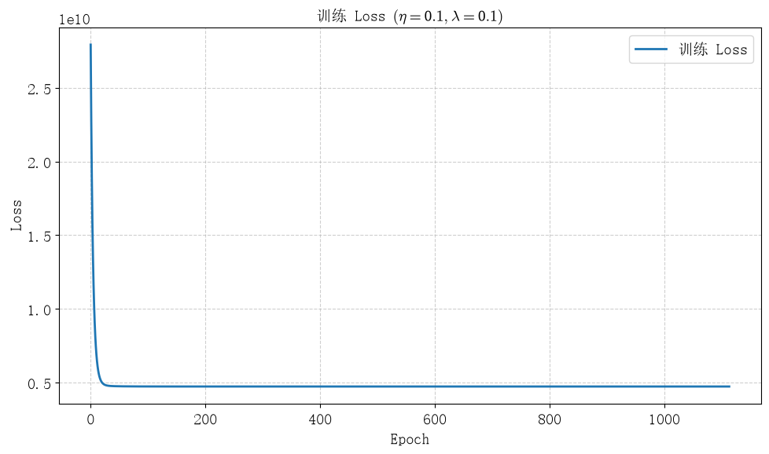

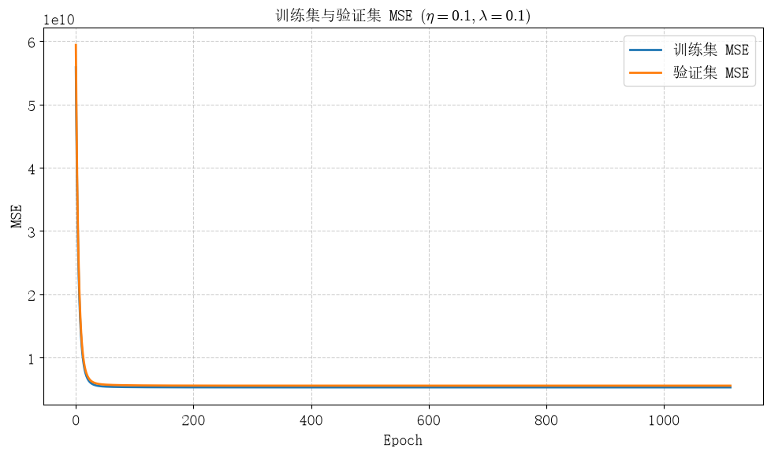

```python
rng = np.random.default_rng(3407)
w_init = rng.normal(0.0, 1.0, X_train.shape[1])

max_epochs = 20000
lr = 0.1
lam = 0.1

t_start = time.time()
w_es, loss_history_es, train_mse_history_es, val_mse_history_es, best_epoch = train_early_stop_history(
    X_train, y_train, X_val, y_val,
    w_init, max_epochs, lr, lam, patience=500, min_delta=1e-5
)
print(f"训练结束，耗时：{time.time()-t_start:.3f}s")
print(f"实际训练轮数：{len(loss_history_es)-1}")
print(f"最优 Epoch：{best_epoch}")
print(f"最优验证集 MSE：{val_mse_history_es[best_epoch]:.6g}")

fig_loss, fig_mse = plot_training_history(
    loss_history_es, train_mse_history_es, val_mse_history_es,
    f" $ (\\eta={lr},\\lambda={lam}) $"
)
display_inline(fig_loss)
display_inline(fig_mse)
```

从图中可以看到，训练初期训练集和验证集 MSE 均快速下降，之后逐渐趋于稳定. 使用 Early Stop 后，无需人为事先确定一个精确的 Epoch 数量，即可自动在验证集误差不再明显改善时停止训练.

同时，后续参数扫描中我们也使用验证集 MSE 最小时对应的 Epoch 和参数，而不是直接使用固定训练轮数结束时的参数.

## 超参调优

### 学习率与 Epoch 与最优 MSE

学习率 $\eta$ 主要决定梯度下降每一次参数更新的步长. 学习率过小时，虽然系统通常能够稳定收敛，但是需要大量 Epoch；学习率过大时，则可能在极小值附近发生振荡，甚至直接发散.

这里我们扫描不同学习率下模型的最优 MSE 以及需要的训练轮数，观察 MSE 和所需训练轮数与学习率的关系.

学习率我们取 $1$ 到 $10^-5$ 按对数均匀取 $50$ 个点.

```python
@nb.njit()
def train_best_quad(X_train, y_train, X_val, y_val,
                    w_init, max_epochs, lr, lam, patience=500, min_delta=1e-5):
    A_train, b_train, c_train = build_quadratic_terms(X_train, y_train)
    A_val, b_val, c_val = build_quadratic_terms(X_val, y_val)
    w = w_init.copy()
    best_w = w.copy()
    best_train = mse_from_terms(w, A_train, b_train, c_train)
    best_val = mse_from_terms(w, A_val, b_val, c_val)
    best_epoch = 0
    wait = 0
    for epoch in range(1, max_epochs + 1):
        w -= lr*(A_train @ w - b_train + lam*w)
        val_mse = mse_from_terms(w, A_val, b_val, c_val)
        if not np.isfinite(val_mse) or val_mse > 1e100: break
        if val_mse < best_val*(1.0 - min_delta):
            best_val = val_mse
            best_train = mse_from_terms(w, A_train, b_train, c_train)
            best_epoch = epoch; best_w = w.copy()
            wait = 0
        else:
            wait += 1
            if wait >= patience: break
    return best_w, best_train, best_val, best_epoch

@nb.njit(parallel=True)
def scan_learning_rates(lrs, X_train, y_train, X_val, y_val,
                        w_init, max_epochs, lam, patience=500, min_delta=1e-5):
    n = lrs.size
    train_mse = np.empty(n)
    val_mse = np.empty(n)
    best_epoch = np.empty(n, dtype=np.int64)
    for i in nb.prange(n):
        _, train_mse[i], val_mse[i], best_epoch[i] = train_best_quad(
            X_train, y_train, X_val, y_val,
            w_init, max_epochs, lrs[i], lam, patience, min_delta
        )
    return train_mse, val_mse, best_epoch
```

```python
lrs = np.logspace(0, -5, 50)
lam_scan = 0.1

# 第一次调用包含 Numba 编译，先进行一次预热
_ = scan_learning_rates(
    lrs[:2], X_train, y_train, X_val, y_val,
    w_init, 10, lam_scan, 5, 1e-5
)

t_start = time.time()
print("开始扫描......")
train_mse_lr, val_mse_lr, epoch_lr = scan_learning_rates(
    lrs, X_train, y_train, X_val, y_val,
    w_init, 20000, lam_scan, 500, 1e-5
)
print(f"扫描结束，耗时：{time.time()-t_start:.3f}s")
```

```
开始扫描......
扫描结束，耗时：1.261s
```

绘图：

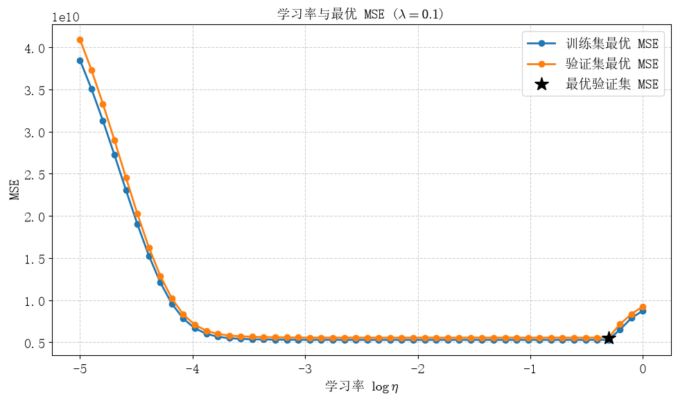

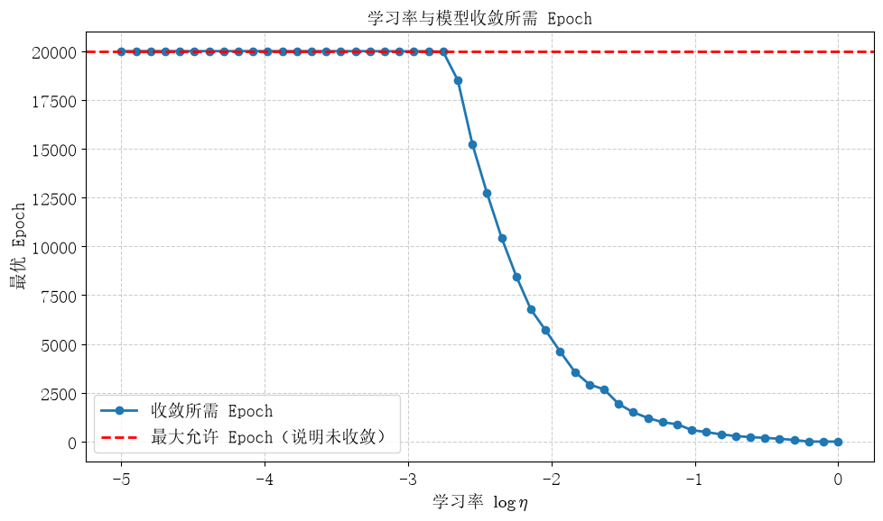

```python
fig, ax = plt.subplots(figsize=(10, 6))
ax.plot(np.log10(lrs), train_mse_lr, marker="o", linewidth=2, label="训练集最优 MSE")
ax.plot(np.log10(lrs), val_mse_lr, marker="o", linewidth=2, label="验证集最优 MSE")
ax.plot(np.log10(lrs[np.argmin(val_mse_lr)]), np.min(val_mse_lr), marker='*', ms=15, ls="None", c='k',  label="最优验证集 MSE")
ax.set_xlabel(r"学习率 $\log\eta$"); ax.set_ylabel("MSE")
ax.set_title(r"学习率与最优 MSE ($\lambda=0.1$)")
ax.grid(True, linestyle="--", alpha=0.6); ax.legend()
display_inline(fig)

fig, ax = plt.subplots(figsize=(10, 6))
ax.plot(np.log10(lrs), epoch_lr, marker="o", linewidth=2, label="收敛所需 Epoch")
ax.axhline(20000, linestyle="--", linewidth=2, color='r', label="最大允许 Epoch（说明未收敛）")
ax.set_xlabel(r"学习率 $\log \eta$"); ax.set_ylabel("最优 Epoch")
ax.set_title(r"学习率与模型收敛所需 Epoch")
ax.grid(True, linestyle="--", alpha=0.6); ax.legend()
display_inline(fig)
```

可以看到，学习率越小，收敛所需要的 Epoch 越大，当学习率过小时，$20000$ 轮内仍旧不能收敛，导致最后的 MSE 上升.

学习率在 $10^{-2}\sim10^{-1}$ 数量级内，最后到的 MSE 基本相同. 这是因为我们的 Loss Function 是一个**凸函数**，因此有唯一确定的极小值点且通过梯度下降一定能取到这个点. 不同的学习率决定不同的步长，使得需要不同 Epoch 才能收敛.

当学习率过大时（$\sim 1$），由于步长较大，最后会在极值点附近振荡，因此无法达到极值点.

之后我们选取 $10^{-1}$ 作为我们的学习率，以平衡所需要的 Epoch 和计算精度.

### L2 系数与最优 MSE

下面固定前面选取的学习率，改变 L2 正则化系数 $\lambda$.

L2 正则化会限制参数 $w$ 的大小，在模型自由度较高时可以降低过拟合. 但是如果 $\lambda$ 过大，也会过度限制模型参数，使模型出现欠拟合.

因此扫描不同 $\lambda$，对每一个 $\lambda$ 均使用 Early Stop 自动确定 Epoch，并使用验证集 MSE 选择最优正则化强度.

```python
@nb.njit(parallel=True)
def scan_lams_parallel(lams, X_train, y_train, X_val, y_val,
                       w_init, max_epochs, lr, patience=500, min_delta=1e-5):
    n = lams.size
    train_mse = np.empty(n)
    val_mse = np.empty(n)
    best_epoch = np.empty(n, dtype=np.int64)
    for i in nb.prange(n):
        _, train_mse[i], val_mse[i], best_epoch[i] = train_best_quad(
            X_train, y_train, X_val, y_val,
            w_init, max_epochs, lr, lams[i], patience, min_delta
        )

    return train_mse, val_mse, best_epoch
```

根据前一小节结论，固定学习率 $\eta=10^{-1}$，进行学习，L2 正则化系数 $\lambda$ 在 $10$ 到 $10^{-10}$ 之间按对数均匀取 $100$ 个点.

```python
lams = np.logspace(-10, 1, 100)
lr = 0.1

# 第一次调用包含 Numba 编译，先进行一次预热
_ = scan_lams_parallel(
    lams[:2], X_train, y_train, X_val, y_val,
    w_init, 10, lr, 5, 1e-5
)

t_start = time.time()
print("开始扫描......")
train_mse_lam, val_mse_lam, epoch_lam = scan_lams_parallel(
    lams, X_train, y_train, X_val, y_val,
    w_init, 20000, lr, 500, 1e-5
)
print(f"L2 扫描耗时：{time.time()-t_start:.3f}s")
```

```
开始扫描......
L2 扫描耗时：0.825s
```

绘图：

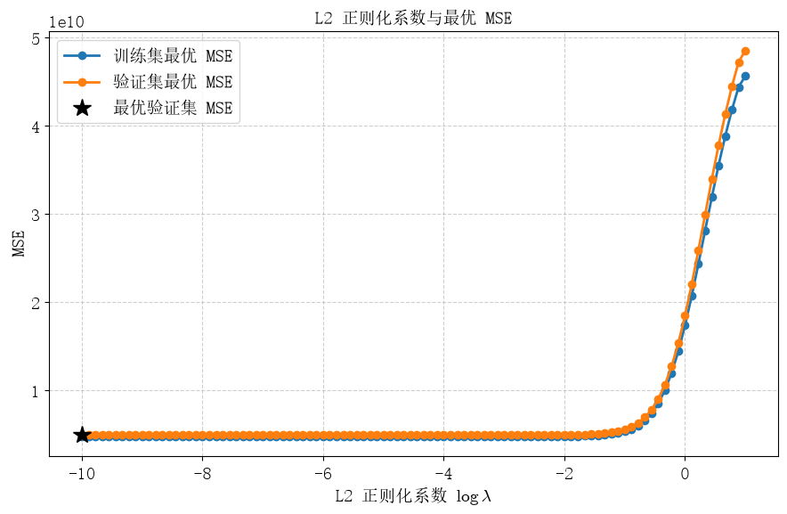

```python
fig, ax = plt.subplots(figsize=(10, 6))
ax.plot(np.log10(lams), train_mse_lam, marker="o", linewidth=2, label="训练集最优 MSE")
ax.plot(np.log10(lams), val_mse_lam, marker="o", linewidth=2, label="验证集最优 MSE")
ax.plot(np.log10(lams[np.argmin(val_mse_lam)]), np.min(val_mse_lam), marker='*', ms=15, ls="None", c='k',  label="最优验证集 MSE")
ax.set_xlabel(r"L2 正则化系数 $\log \lambda$"); ax.set_ylabel("MSE")
ax.set_title("L2 正则化系数与最优 MSE")
ax.grid(True, linestyle="--", alpha=0.6); ax.legend()
display_inline(fig)
```

在当前数据集和数据划分下，随着 $\lambda$ 增大，验证集 MSE 并没有进一步下降，反而逐渐增大，最优结果出现在 $\lambda=0$ 附近.

这说明当前模型只有较少的一阶特征，而训练数据量较大，模型本身没有表现出明显的高方差问题. 因此 L2 正则化带来的参数收缩反而会增加模型偏差. 后续模型使用 $\lambda=0$.

### 最优超参

综上，我们得到了对于我们的线性回归模型而言，最优的超参：

- 学习率 $\eta=0.1$
- L2 正则化系数 $\lambda=0$
- 训练轮数通过验证集合 MSE 是否继续下降来自动判定

在这个参数下训练模型，此时，模型在训练集、验证集、测试集的预测与真实的对比和残差曲线以及 MSE 和 $R^2$ 为：

```python
X_test, y_test = gen_features(test_df)
X_test = normalize_features(X_test, mu_train, sigma_train)

lr = 0.1
lam = 0.0
max_epochs = 20000

w, _, _, _ = train_best_quad(
    X_train, y_train, X_val, y_val,
    w_init, max_epochs, lr, lam,
    patience=500, min_delta=1e-8
)
```

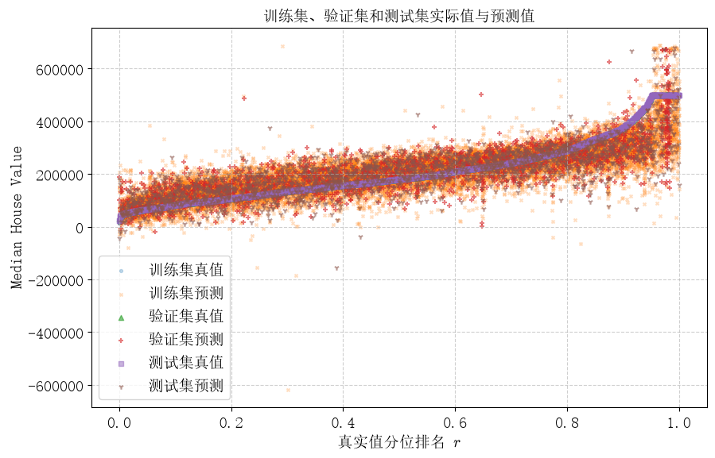

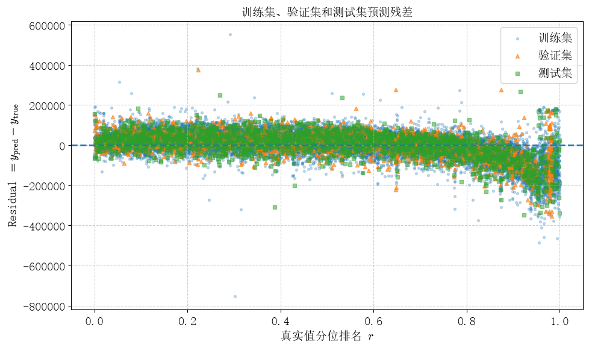

```python
y_train_pred = X_train @ w
y_val_pred = X_val @ w
y_test_pred = X_test @ w

y_true = np.concatenate([y_train, y_val, y_test])
y_pred = np.concatenate([y_train_pred, y_val_pred, y_test_pred])
data_type = np.concatenate([np.zeros(y_train.size), np.ones(y_val.size), np.full(y_test.size, 2)])

idx = np.argsort(y_true)
y_true = y_true[idx]; y_pred = y_pred[idx]; data_type = data_type[idx]
residual = y_pred-y_true; rank = np.linspace(0, 1, y_true.size)

train_mask = (data_type == 0)
val_mask = (data_type == 1)
test_mask = (data_type == 2)

fig, ax = plt.subplots(figsize=(10, 6))

ax.scatter(rank[train_mask], y_true[train_mask], marker="o", s=8, alpha=0.25, label="训练集真值")
ax.scatter(rank[train_mask], y_pred[train_mask], marker="x", s=8, alpha=0.25, label="训练集预测")
ax.scatter(rank[val_mask], y_true[val_mask], marker="^", s=20, alpha=0.6, label="验证集真值")
ax.scatter(rank[val_mask], y_pred[val_mask], marker="+", s=20, alpha=0.6, label="验证集预测")
ax.scatter(rank[test_mask], y_true[test_mask], marker="s", s=16, alpha=0.5, label="测试集真值")
ax.scatter(rank[test_mask], y_pred[test_mask], marker="1", s=22, alpha=0.6, label="测试集预测")

ax.set_title("训练集、验证集和测试集实际值与预测值")
ax.set_xlabel(r"真实值分位排名 $r$"); ax.set_ylabel("Median House Value")
ax.grid(True, linestyle="--", alpha=0.6); ax.legend()
display_inline(fig)

fig, ax = plt.subplots(figsize=(10, 6))

ax.scatter(rank[train_mask], residual[train_mask], marker="o", s=8, alpha=0.25, label="训练集")
ax.scatter(rank[val_mask], residual[val_mask], marker="^", s=20, alpha=0.6, label="验证集")
ax.scatter(rank[test_mask], residual[test_mask], marker="s", s=16, alpha=0.5, label="测试集")
ax.axhline(0, linestyle="--", linewidth=2)

ax.set_title("训练集、验证集和测试集预测残差")
ax.set_xlabel(r"真实值分位排名 $r$")
ax.set_ylabel(r"Residual $=y_{\mathrm{pred}}-y_{\mathrm{true}}$")
ax.grid(True, linestyle="--", alpha=0.6); ax.legend()

display_inline(fig)
```

```python
result_df = pd.DataFrame({
    "数据集": ["Train", "Val", "Test"],
    "MSE": [
        mse_function(y_train_pred, y_train),
        mse_function(y_val_pred, y_val),
        mse_function(y_test_pred, y_test)
    ],
    "R^2": [
        r2_function(y_train_pred, y_train),
        r2_function(y_val_pred, y_val),
        r2_function(y_test_pred, y_test)
    ]
})
display(result_df)
```

|  | 数据集 | MSE | R^2 |
| --- | --- | --- | --- |
| 0 | Train | 4.707690e+09 | 0.645644 |
| 1 | Val | 4.852549e+09 | 0.658633 |
| 2 | Test | 4.718696e+09 | 0.626137 |

## 不同数据预处理方法下模型对比

### 自动确定最优 L2 系数

前面已经实现了 Early Stop 和 L2 正则化. 为了方便后续对不同数据预处理方法进行公平比较, 这里进一步将 L2 系数选择过程封装为一个函数.

函数传入候选的 L2 系数 `lams`、训练集和验证集, 自动完成:

1. 对每一个 $\lambda$ 分别训练模型.
2. 使用 Early Stop 自动确定每一个 $\lambda$ 对应的最优 Epoch.
3. 记录对应的训练集 MSE 和验证集 MSE.
4. 以验证集 MSE 最小作为标准, 自动确定最优 $\lambda$.
5. 返回最优模型参数、最优 L2 系数以及最优验证集 `best_mse`.

```python
def train_auto_l2(lams, X_train, y_train, X_val, y_val, lr=0.1, max_epochs=20000, patience=500, min_delta=1e-5, random_state=3407):
    lams = np.asarray(lams)
    w_init = rng.normal(0.0, 1.0, X_train.shape[1])

    records = []
    best_mse, best_lam, best_epoch, w_best = np.inf, None, None, None

    for lam in lams:
        w, train_mse, val_mse, epoch = train_best_quad(
            X_train, y_train, X_val, y_val, w_init,
            max_epochs, lr, lam, patience, min_delta
        )
        if np.isfinite(val_mse) and val_mse < best_mse:
            best_mse, best_lam, best_epoch, w_best = val_mse, lam, epoch, w.copy()
    return w_best, best_lam, best_mse, best_epoch
```

### 缺失值处理方法对比

前面对于 `total_bedrooms` 的缺失值采用了中位数填补. 这里进一步比较三种常见的缺失值处理方法: 直接丢弃缺失样本、中位数填补和平均值填补.

为了使三组结果能够直接比较, 三种方法使用完全相同的验证集. 因此将所有含缺失值的样本保留在训练集中, 再分别对训练集执行删除、平均值填补和中位数填补.

```python
def split_housing_raw(data, random_state=3407):
    n_train, n_val = int(len(data) * 0.8), int(len(data) * 0.1)
    miss_mask = data.isnull().any(axis=1)
    data_miss = data.loc[miss_mask].copy()
    data_nomiss = data.loc[~miss_mask].sample(frac=1, random_state=random_state).copy()
    n_train_nomiss = n_train - len(data_miss)
    train_raw = pd.concat([data_miss, data_nomiss.iloc[:n_train_nomiss]], axis=0)
    val_raw = data_nomiss.iloc[n_train_nomiss:n_train_nomiss + n_val].copy()
    test_raw = data_nomiss.iloc[n_train_nomiss + n_val:].copy()
    return train_raw.reset_index(drop=True), val_raw.reset_index(drop=True), test_raw.reset_index(drop=True)

train_raw, val_raw, test_raw = split_housing_raw(df)

def preprocess_missing(train_raw, val_raw, test_raw, method="median"):
    train_data, val_data, test_data = train_raw.copy(), val_raw.copy(), test_raw.copy()

    if method == "drop":
        train_data = train_data.dropna().copy()
    elif method in ["median", "mean"]:
        value = train_data["total_bedrooms"].median() if method == "median" else train_data["total_bedrooms"].mean()
        train_data["total_bedrooms"] = train_data["total_bedrooms"].fillna(value)
        val_data["total_bedrooms"] = val_data["total_bedrooms"].fillna(value)
        test_data["total_bedrooms"] = test_data["total_bedrooms"].fillna(value)
    else:
        raise ValueError("method 必须为 drop、median 或 mean")

    train_data, val_data, test_data = encode_ocean_proximity(train_data), encode_ocean_proximity(val_data), encode_ocean_proximity(test_data)
    val_data = val_data.reindex(columns=train_data.columns, fill_value=0)
    test_data = test_data.reindex(columns=train_data.columns, fill_value=0)

    X_train_raw, y_train = gen_features(train_data)
    X_val_raw, y_val = gen_features(val_data)
    X_test_raw, y_test = gen_features(test_data)

    mean, std = X_train_raw[:, 1:].mean(axis=0), X_train_raw[:, 1:].std(axis=0)
    std[std < 1e-12] = 1.0

    X_train = normalize_features(X_train_raw, mean, std)
    X_val = normalize_features(X_val_raw, mean, std)
    X_test = normalize_features(X_test_raw, mean, std)

    return X_train, y_train, X_val, y_val, X_test, y_test
```

分别计算三种缺失值的处理方案，并绘制 MSE 柱型图：

```python
missing_methods = {
    "drop": "丢弃缺失值",
    "median": "中位数填补",
    "mean": "平均值填补"
}

missing_results = []

for method, name in missing_methods.items():
    X_tr, y_tr, X_va, y_va, X_te, y_te = preprocess_missing(train_raw, val_raw, test_raw, method)

    w, _, best_mse, _ = train_auto_l2(lams, X_tr, y_tr, X_va, y_va)

    train_mse = mse_function(X_tr @ w, y_tr)
    val_mse = mse_function(X_va @ w, y_va)
    test_mse = mse_function(X_te @ w, y_te)

    missing_results.append({
        "方法": name,
        "训练集 MSE": train_mse,
        "验证集 MSE": val_mse,
        "测试集 MSE": test_mse,
    })

missing_result_df = pd.DataFrame(missing_results)
display(missing_result_df)
```

|  | 方法 | 训练集 MSE | 验证集 MSE | 测试集 MSE |
| --- | --- | --- | --- | --- |
| 0 | 丢弃缺失值 | 4.696300e+09 | 4.855129e+09 | 4.713223e+09 |
| 1 | 中位数填补 | 4.707775e+09 | 4.852573e+09 | 4.718594e+09 |
| 2 | 平均值填补 | 4.707530e+09 | 4.852597e+09 | 4.718133e+09 |

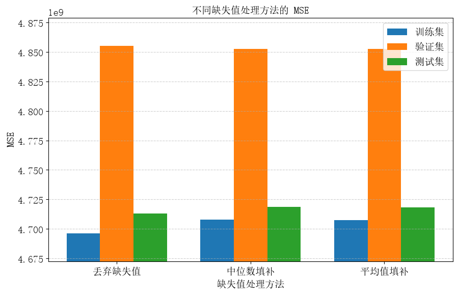

```python
x = np.arange(len(missing_result_df))
width = 0.25

fig, ax = plt.subplots(figsize=(10, 6))

bars1 = ax.bar(x - width, missing_result_df["训练集 MSE"], width, label="训练集")
bars2 = ax.bar(x, missing_result_df["验证集 MSE"], width, label="验证集")
bars3 = ax.bar(x + width, missing_result_df["测试集 MSE"], width, label="测试集")

ax.set_title("不同缺失值处理方法的 MSE")
ax.set_xlabel("缺失值处理方法")
ax.set_ylabel("MSE")
ax.set_xticks(x)
ax.set_xticklabels(missing_result_df["方法"])
mse_min = missing_result_df[["训练集 MSE", "验证集 MSE", "测试集 MSE"]].to_numpy().min()
mse_max = missing_result_df[["训练集 MSE", "验证集 MSE", "测试集 MSE"]].to_numpy().max()
margin = max((mse_max - mse_min) * 0.15, 1e7)
ax.set_ylim(mse_min - margin, mse_max + margin)
ax.grid(True, axis="y", linestyle="--", alpha=0.6)
ax.legend()

display_inline(fig)
```

从结果可以看到, 三种缺失值处理方法得到的模型性能非常接近. 丢弃缺失值、中位数填补和平均值填补对应的验证集 MSE 分别约为 $4.8551\times10^9$、$4.8526\times10^9$ 和 $4.8526\times10^9$.

其中, 中位数填补的验证集 MSE 最小, 但与平均值填补之间的差异很小. 这是因为 `total_bedrooms` 仅有少量数据缺失, 因此不同缺失值处理方式对整体模型性能的影响较弱.

虽然直接丢弃缺失值时训练集和测试集 MSE 略低, 但是模型及数据预处理方法的选择应根据验证集而不是测试集进行. 因此根据验证集结果, 后续仍采用中位数填补. 同时, 由于 `total_bedrooms` 的分布存在一定的右偏和长尾特征, 中位数相比平均值也具有更好的稳健性.

### 文本编码方式对比

前面对于字符串特征 `ocean_proximity` 使用了 Onehot 编码. 为了研究不同文本特征处理方法对模型性能的影响, 这里进一步比较以下四种方法:

1. 使用 Onehot 编码, 将不同类别分别作为独立特征.
2. 使用 Onehot 编码, 将不同类别分别作为独立特征,但去除一组，防止线性相关.
3. 根据类别与海岸的关系构造一个离海岸相关的数值编码.
4. 完全删除 `ocean_proximity`, 即不使用这一文本特征.

对于离海岸相关编码, 根据不同类别的地理含义定义

$$ \mathrm{INLAND}\rightarrow0,\qquad <1\mathrm{H\ OCEAN}\rightarrow1, $$

$$ \mathrm{NEAR\ BAY}\rightarrow2,\qquad \mathrm{NEAR\ OCEAN}\rightarrow2,\qquad \mathrm{ISLAND}\rightarrow3. $$

这里的数值仅表示人为定义的相对接近海岸程度, 并不表示真实的地理距离. 这种编码能够将原来的多个类别特征压缩为一个数值特征, 但同时人为引入了类别之间存在顺序关系的假设.

为了只研究文本编码方式的影响, 四组实验中的缺失值均使用上一节确定的中位数填补. 对每一种编码方式分别重新进行标准化、L2 系数自动搜索和模型训练, 并比较训练集、验证集和测试集 MSE.

```python
coast_map = {"INLAND": 0.0, "<1H OCEAN": 1.0, "NEAR BAY": 2.0, "NEAR OCEAN": 2.0, "ISLAND": 3.0}

def encode_ocean_drop(data, base="INLAND"):
    data = encode_ocean_proximity(data)
    return data.drop(columns=[f"ocean_proximity_{base}"])

def preprocess_ocean(train_raw, val_raw, test_raw, method="onehot"):
    train_data, val_data, test_data = train_raw.copy(), val_raw.copy(), test_raw.copy()

    median_value = train_data["total_bedrooms"].median()
    for data in (train_data, val_data, test_data): data["total_bedrooms"] = data["total_bedrooms"].fillna(median_value)

    if method == "onehot":
        train_data, val_data, test_data = encode_ocean_proximity(train_data), encode_ocean_proximity(val_data), encode_ocean_proximity(test_data)
    elif method == "onehot_drop":
        train_data, val_data, test_data = encode_ocean_drop(train_data), encode_ocean_drop(val_data), encode_ocean_drop(test_data)
    elif method == "coast":
        for data in (train_data, val_data, test_data): data["ocean_proximity"] = data["ocean_proximity"].map(coast_map)
        train_data = train_data.rename(columns={"ocean_proximity": "coast_proximity"}); val_data = val_data.rename(columns={"ocean_proximity": "coast_proximity"}); test_data = test_data.rename(columns={"ocean_proximity": "coast_proximity"})
    elif method == "drop":
        train_data = train_data.drop(columns=["ocean_proximity"]); val_data = val_data.drop(columns=["ocean_proximity"]); test_data = test_data.drop(columns=["ocean_proximity"])
    else:
        raise ValueError("method 必须为 onehot、onehot_drop、coast 或 drop")

    val_data = val_data.reindex(columns=train_data.columns, fill_value=0); test_data = test_data.reindex(columns=train_data.columns, fill_value=0)

    X_train_raw, y_train = gen_features(train_data); X_val_raw, y_val = gen_features(val_data); X_test_raw, y_test = gen_features(test_data)
    mean, std = X_train_raw[:, 1:].mean(axis=0), X_train_raw[:, 1:].std(axis=0); std[std < 1e-12] = 1.0
    X_train = normalize_features(X_train_raw, mean, std); X_val = normalize_features(X_val_raw, mean, std); X_test = normalize_features(X_test_raw, mean, std)

    return X_train, y_train, X_val, y_val, X_test, y_test
```

分别使用四种文本特征处理方法训练模型.

```python
ocean_methods = {
    "onehot": "完整 Onehot",
    "onehot_drop": "Onehot 去除一组",
    "coast": "离海岸相关编码",
    "drop": "不使用文本"
}

ocean_results = []

for method, name in ocean_methods.items():
    X_tr, y_tr, X_va, y_va, X_te, y_te = preprocess_ocean(train_raw, val_raw, test_raw, method)
    w, best_lam, best_mse, best_epoch = train_auto_l2(lams, X_tr, y_tr, X_va, y_va)

    ocean_results.append({
        "方法": name,
        "特征数": X_tr.shape[1]-1,
        "最优 L2": best_lam,
        "最优 Epoch": best_epoch,
        "训练集 MSE": mse_function(X_tr @ w, y_tr),
        "验证集 MSE": mse_function(X_va @ w, y_va),
        "测试集 MSE": mse_function(X_te @ w, y_te)
    })

ocean_result_df = pd.DataFrame(ocean_results)
display(ocean_result_df)
```

|  | 方法 | 特征数 | 最优 L2 | 最优 Epoch | 训练集 MSE | 验证集 MSE | 测试集 MSE |
| --- | --- | --- | --- | --- | --- | --- | --- |
| 0 | 完整 Onehot | 13 | 1.000000e-10 | 1271 | 4.707775e+09 | 4.852573e+09 | 4.718594e+09 |
| 1 | Onehot 去除一组 | 12 | 1.000000e-10 | 1250 | 4.707813e+09 | 4.852577e+09 | 4.718625e+09 |
| 2 | 离海岸相关编码 | 9 | 1.668101e-05 | 1075 | 4.771420e+09 | 4.898036e+09 | 4.817290e+09 |
| 3 | 不使用文本 | 8 | 1.000000e-10 | 1039 | 4.833460e+09 | 4.994905e+09 | 4.880076e+09 |

绘制训练集、验证集和测试集 MSE 的分组柱形图.

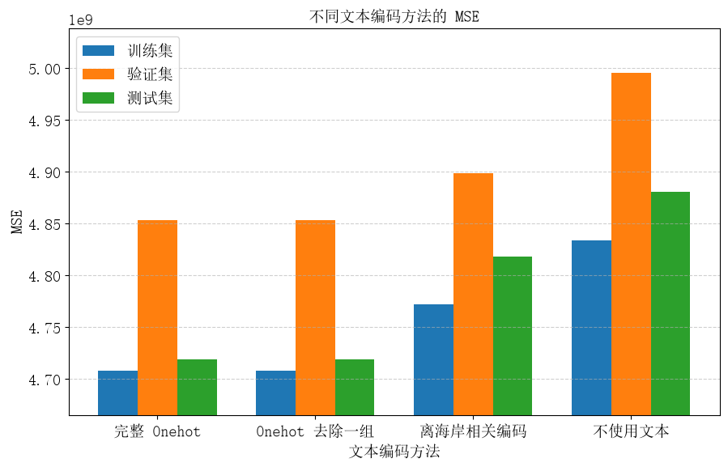

```python
x = np.arange(len(ocean_result_df)); width = 0.25

fig, ax = plt.subplots(figsize=(10, 6))
ax.bar(x-width, ocean_result_df["训练集 MSE"], width, label="训练集")
ax.bar(x, ocean_result_df["验证集 MSE"], width, label="验证集")
ax.bar(x+width, ocean_result_df["测试集 MSE"], width, label="测试集")

ax.set_title("不同文本编码方法的 MSE")
ax.set_xlabel("文本编码方法"); ax.set_ylabel("MSE")
ax.set_xticks(x); ax.set_xticklabels(ocean_result_df["方法"])
ax.grid(True, axis="y", linestyle="--", alpha=0.6); ax.legend()

mse_min = ocean_result_df[["训练集 MSE", "验证集 MSE", "测试集 MSE"]].to_numpy().min()
mse_max = ocean_result_df[["训练集 MSE", "验证集 MSE", "测试集 MSE"]].to_numpy().max()
margin = max((mse_max-mse_min)*0.15, 1e7); ax.set_ylim(mse_min-margin, mse_max+margin)

display_inline(fig)
```

根据实验结果, 不同文本编码方式对模型性能存在较明显的影响.

但是完整 Onehot 编码中, 5 个 Onehot 特征之和恒为 $1$, 与模型中的常数项存在严格线性相关. 去除其中一个类别后, 特征数由 $13$ 减少为 $12$, 同时消除了这一严格线性相关关系. 因此在模型性能基本不变的情况下, 去除一组 Onehot 是更合理的处理方法.

离海岸相关编码的验证集 MSE 为 $4.898036\times10^9$, 测试集 MSE 为 $4.817290\times10^9$, 均高于两种 Onehot 编码. 这说明 `ocean_proximity` 中包含的信息不能简单表示为一个单调的"离海岸远近"关系. `NEAR BAY`、`NEAR OCEAN` 和 `<1H OCEAN` 等类别除了与海岸距离有关外, 还可能包含区域位置、城市分布以及住房市场差异等信息. 将多个类别压缩为一个数值特征会损失部分有效信息.

完全删除 `ocean_proximity` 后, 验证集 MSE 进一步增大到 $4.994905\times10^9$, 测试集 MSE 增大到 $4.880076\times10^9$. 说明 `ocean_proximity` 本身包含了对房价预测有用的信息, 直接删除这一特征会降低模型的预测能力.

综合来看, Onehot 编码能够较完整地保留 `ocean_proximity` 中的类别信息. 完整 Onehot 和去除一组 Onehot 的预测性能基本一致, 但后者能够避免与常数项之间的严格线性相关. 因此后续模型采用去除一个基准类别的 Onehot 编码处理 `ocean_proximity`.

### 人工构造特征对比

我们重新分析特征：

```python
feature_names = [col for col in train_df.columns if col != "median_house_value"]
feature_names
```

```
['longitude',
 'latitude',
 'housing_median_age',
 'total_rooms',
 'total_bedrooms',
 'population',
 'households',
 'median_income',
 'ocean_proximity_<1H OCEAN',
 'ocean_proximity_INLAND',
 'ocean_proximity_ISLAND',
 'ocean_proximity_NEAR BAY',
 'ocean_proximity_NEAR OCEAN']
```

原始数据中的 `total_rooms`、`total_bedrooms`、`population` 和 `households` 均为区域总量. 但对于房价预测而言, 单纯使用总量可能无法直接反映区域内部住房结构. 因此这里进一步利用已有特征构造一些具有明确含义的比例特征.

定义

$$ \mathrm{rooms\_per\_household}=\frac{\mathrm{total\_rooms}}{\mathrm{households}} $$

表示平均每户拥有的房间数.

$$ \mathrm{bedrooms\_per\_household} =\frac{\mathrm{total\_bedrooms}}{\mathrm{households}} $$

表示平均每户拥有的卧室数.

$$ \mathrm{bedrooms\_per\_room}= \frac{\mathrm{total\_bedrooms}}{\mathrm{total\_rooms}} $$

表示卧室数占总房间数的比例.

$$ \mathrm{population\_per\_room}= \frac{\mathrm{population}}{\mathrm{total\_rooms}} $$

表示平均每个房间对应的人口数量, 可以在一定程度上反映区域住房的拥挤程度.

为了研究不同人工特征对模型性能的影响, 分别进行以下实验:

1. 只使用原始特征, 不加入人工构造特征.
2. 单独加入 `rooms_per_household`.
3. 单独加入 `bedrooms_per_household`.
4. 单独加入 `bedrooms_per_room`.
5. 单独加入 `population_per_room`.
6. 同时加入以上 4 个人工构造特征.

```python
ratio_features = ["rooms_per_household", "bedrooms_per_household", "bedrooms_per_room", "population_per_room"]

def add_ratio_features(data, features):
    data = data.copy(); eps = 1e-6
    if "rooms_per_household" in features: data["rooms_per_household"] = data["total_rooms"]/(data["households"]+eps)
    if "bedrooms_per_household" in features: data["bedrooms_per_household"] = data["total_bedrooms"]/(data["households"]+eps)
    if "bedrooms_per_room" in features: data["bedrooms_per_room"] = data["total_bedrooms"]/(data["total_rooms"]+eps)
    if "population_per_room" in features: data["population_per_room"] = data["population"]/(data["total_rooms"]+eps)
    return data

def preprocess_ratio_features(train_raw, val_raw, test_raw, features=()):
    train_data, val_data, test_data = train_raw.copy(), val_raw.copy(), test_raw.copy()

    median_value = train_data["total_bedrooms"].median()
    for data in (train_data, val_data, test_data): data["total_bedrooms"] = data["total_bedrooms"].fillna(median_value)

    train_data = add_ratio_features(train_data, features); val_data = add_ratio_features(val_data, features); test_data = add_ratio_features(test_data, features)

    train_data = encode_ocean_drop(train_data); val_data = encode_ocean_drop(val_data); test_data = encode_ocean_drop(test_data)
    val_data = val_data.reindex(columns=train_data.columns, fill_value=0); test_data = test_data.reindex(columns=train_data.columns, fill_value=0)

    X_tr_raw, y_tr = gen_features(train_data); X_va_raw, y_va = gen_features(val_data); X_te_raw, y_te = gen_features(test_data)
    mean, std = X_tr_raw[:, 1:].mean(axis=0), X_tr_raw[:, 1:].std(axis=0); std[std < 1e-12] = 1.0

    X_tr = normalize_features(X_tr_raw, mean, std); X_va = normalize_features(X_va_raw, mean, std); X_te = normalize_features(X_te_raw, mean, std)
    return X_tr, y_tr, X_va, y_va, X_te, y_te
```

引入上述项后，重新进行训练，有：

```python
ratio_methods = {
    "原始特征": [],
    "每户房间数": ["rooms_per_household"],
    "每户卧室数": ["bedrooms_per_household"],
    "卧室占比": ["bedrooms_per_room"],
    "每房间人口数": ["population_per_room"],
    "组合人工特征": ratio_features
}

ratio_results = []

for name, features in ratio_methods.items():
    X_tr, y_tr, X_va, y_va, X_te, y_te = preprocess_ratio_features(train_raw, val_raw, test_raw, features)
    w, best_lam, best_mse, best_epoch = train_auto_l2(lams, X_tr, y_tr, X_va, y_va)

    ratio_results.append({
        "方法": name,
        "特征数": X_tr.shape[1]-1,
        "最优 L2": best_lam,
        "最优 Epoch": best_epoch,
        "训练集 MSE": mse_function(X_tr@w, y_tr),
        "验证集 MSE": mse_function(X_va@w, y_va),
        "测试集 MSE": mse_function(X_te@w, y_te)
    })

ratio_result_df = pd.DataFrame(ratio_results)

base_val = ratio_result_df.loc[0, "验证集 MSE"]; base_test = ratio_result_df.loc[0, "测试集 MSE"]
ratio_result_df["验证集 MSE 变化"] = ratio_result_df["验证集 MSE"]-base_val
ratio_result_df["测试集 MSE 变化"] = ratio_result_df["测试集 MSE"]-base_test

display(ratio_result_df)
```

|  | 方法 | 特征数 | 最优 L2 | 最优 Epoch | 训练集 MSE | 验证集 MSE | 测试集 MSE | 验证集 MSE 变化 | 测试集 MSE 变化 |
| --- | --- | --- | --- | --- | --- | --- | --- | --- | --- |
| 0 | 原始特征 | 12 | 1.000000e-10 | 1250 | 4.707813e+09 | 4.852577e+09 | 4.718625e+09 | 0.000000e+00 | 0.000000e+00 |
| 1 | 每户房间数 | 13 | 1.000000e-10 | 535 | 4.694051e+09 | 4.910609e+09 | 4.710081e+09 | 5.803163e+07 | -8.543742e+06 |
| 2 | 每户卧室数 | 13 | 1.000000e-10 | 666 | 4.694395e+09 | 4.898261e+09 | 4.693544e+09 | 4.568365e+07 | -2.508068e+07 |
| 3 | 卧室占比 | 13 | 1.000000e-10 | 1864 | 4.680629e+09 | 4.813682e+09 | 4.656413e+09 | -3.889543e+07 | -6.221220e+07 |
| 4 | 每房间人口数 | 13 | 1.000000e-10 | 1327 | 4.707726e+09 | 4.852135e+09 | 4.718368e+09 | -4.421175e+05 | -2.572437e+05 |
| 5 | 组合人工特征 | 16 | 3.593814e-07 | 850 | 4.604833e+09 | 4.837516e+09 | 4.576335e+09 | -1.506088e+07 | -1.422905e+08 |

绘制各组 MSE

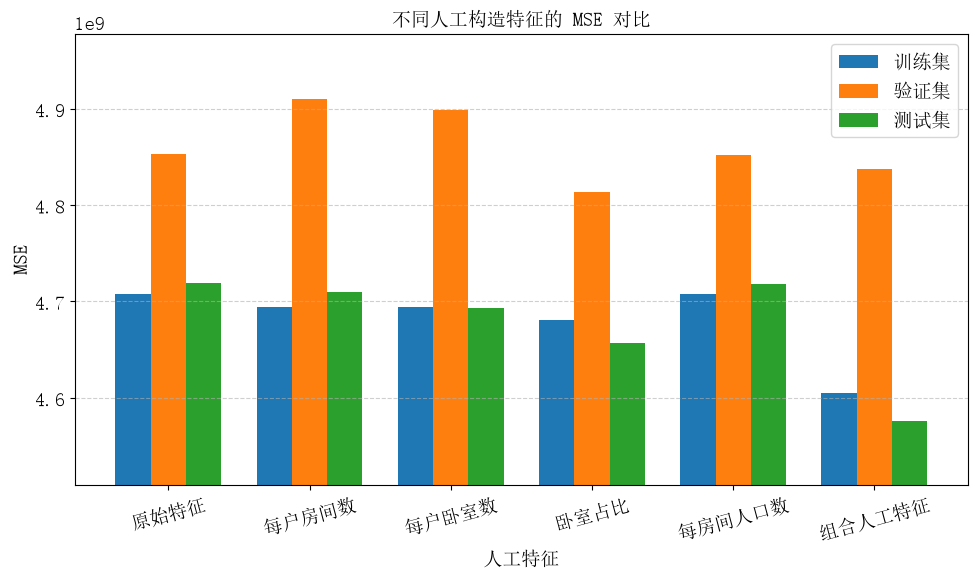

```python
x = np.arange(len(ratio_result_df)); width = 0.25

fig, ax = plt.subplots(figsize=(10, 6))
ax.bar(x-width, ratio_result_df["训练集 MSE"], width, label="训练集")
ax.bar(x, ratio_result_df["验证集 MSE"], width, label="验证集")
ax.bar(x+width, ratio_result_df["测试集 MSE"], width, label="测试集")

ax.set_title("不同人工构造特征的 MSE 对比")
ax.set_xlabel("人工特征"); ax.set_ylabel("MSE")
ax.set_xticks(x); ax.set_xticklabels(ratio_result_df["方法"], rotation=15)
ax.grid(True, axis="y", linestyle="--", alpha=0.6); ax.legend()

mse_min = ratio_result_df[["训练集 MSE", "验证集 MSE", "测试集 MSE"]].to_numpy().min()
mse_max = ratio_result_df[["训练集 MSE", "验证集 MSE", "测试集 MSE"]].to_numpy().max()
margin = max((mse_max-mse_min)*0.2, 1e7); ax.set_ylim(mse_min-margin, mse_max+margin)

fig.tight_layout(); display_inline(fig)
```

根据实验结果, 不同人工构造特征对模型性能的影响存在明显差异.

单独加入 `rooms_per_household` 后, 训练集 MSE 有所下降, 但验证集 MSE 从 $4.852577\times10^9$ 增大到 $4.910608\times10^9$, 说明该特征没有提高模型在未见数据上的预测能力. `bedrooms_per_household` 也表现出类似现象, 验证集 MSE 增大到 $4.898262\times10^9$. 因此这两个特征单独加入时均没有带来有效改善.

`population_per_room` 对模型结果的影响很小. 加入后验证集 MSE 为 $4.852135\times10^9$, 与原始模型的 $4.852577\times10^9$ 基本一致, 说明该特征提供的额外有效信息有限.

相比之下, `bedrooms_per_room` 的改善最明显. 加入该特征后, 验证集 MSE 降低到

$$ 4.813682\times10^9 $$

相比原始模型降低约 $3.89\times10^7$, 测试集 MSE 也由 $4.718625\times10^9$ 降低到

$$ 4.656413\times10^9 $$

这说明卧室数占总房间数的比例能够提供原始总量特征中没有直接表达的住房结构信息, 对房价预测具有实际作用.

同时加入全部 4 个人工特征后, 训练集 MSE 进一步降低到 $4.604833\times10^9$, 测试集 MSE 也降低到 $4.576334\times10^9$. 但是其验证集 MSE 为 $4.837516\times10^9$, 高于仅加入 `bedrooms_per_room` 时的 $4.813682\times10^9$. 说明增加更多人工特征虽然提高了模型对训练数据的拟合能力, 但并没有在验证集上获得进一步改善.

因此在模型选择过程中, 应以验证集结果为依据, 而不能使用测试集选择模型. 本实验中人工特征部分的最优方案为只加入

$$ \mathrm{bedrooms\_per\_room} =\frac{\mathrm{total\_bedrooms}}{\mathrm{total\_rooms}} $$

该方案在验证集上取得最低 MSE, 同时测试集误差相比原始模型也有明显降低.

### 最优处理方法

综合前面的缺失值、文本特征和人工特征实验, 最终采用以下数据处理方法:

1. `total_bedrooms` 的缺失值使用训练集的中位数进行填补.
2. `ocean_proximity` 使用 Onehot 编码, 并删除 `INLAND` 对应的一组, 将其作为基准类别. 这样既保留类别信息, 又避免完整 Onehot 与常数项之间的严格线性相关.
3. 在原始数值特征基础上增加人工特征

$$ \mathrm{bedrooms\_per\_room} =\frac{\mathrm{total\_bedrooms}}{\mathrm{total\_rooms}}. $$

4. 不加入 `rooms_per_household`、`bedrooms_per_household` 和 `population_per_room`, 因为它们在验证集上没有表现出进一步改善.
5. 所有连续特征使用训练集均值和标准差进行标准化, 验证集和测试集使用相同的标准化参数.
6. 使用验证集自动搜索 L2 正则化系数, 并使用 Early Stop 确定训练停止位置.
7. 测试集只用于最终模型性能评价, 不参与特征选择和超参数选择.

在当前实验中, 最终人工特征方案对应的最优 L2 系数为

$$ \lambda=10^{-10}, $$

因此后续模型使用"中位数填补 + 去除一组的 Onehot 编码 + `bedrooms_per_room` 人工特征 + 标准化 + L2 + Early Stop"作为最终的数据处理与训练方案.

确定了最优的处理方法和最优的模型超参后，重新训练后，有

```python
def preprocess_final_model(train_raw, val_raw, test_raw):
    train_data, val_data, test_data = train_raw.copy(), val_raw.copy(), test_raw.copy(); eps = 1e-6

    median_value = train_data["total_bedrooms"].median()
    for data in (train_data, val_data, test_data):
        data["total_bedrooms"] = data["total_bedrooms"].fillna(median_value)
        data["bedrooms_per_room"] = data["total_bedrooms"]/(data["total_rooms"]+eps)

    train_data = encode_ocean_drop(train_data); val_data = encode_ocean_drop(val_data); test_data = encode_ocean_drop(test_data)
    val_data = val_data.reindex(columns=train_data.columns, fill_value=0); test_data = test_data.reindex(columns=train_data.columns, fill_value=0)

    feature_names = [col for col in train_data.columns if col != "median_house_value"]
    X_train_raw, y_train = gen_features(train_data); X_val_raw, y_val = gen_features(val_data); X_test_raw, y_test = gen_features(test_data)

    mu_train = X_train_raw[:, 1:].mean(axis=0); sigma_train = X_train_raw[:, 1:].std(axis=0); sigma_train[sigma_train < 1e-12] = 1.0
    X_train = normalize_features(X_train_raw, mu_train, sigma_train)
    X_val = normalize_features(X_val_raw, mu_train, sigma_train)
    X_test = normalize_features(X_test_raw, mu_train, sigma_train)

    return X_train, y_train, X_val, y_val, X_test, y_test, feature_names, mu_train, sigma_train

X_train, y_train, X_val, y_val, X_test, y_test, feature_names, mu_train, sigma_train = preprocess_final_model(train_raw, val_raw, test_raw)

best_lam_final = float(ratio_result_df.loc[ratio_result_df["方法"] == "卧室占比", "最优 L2"].iloc[0])
lr_final = 0.1

rng_final = np.random.default_rng(3407)
w_init_final = rng_final.normal(0.0, 1.0, X_train.shape[1])

w_final, loss_history_final, train_mse_history_final, val_mse_history_final, best_epoch_final = train_early_stop_history(
    X_train, y_train, X_val, y_val, w_init_final,
    max_epochs=20000, lr=lr_final, lam=best_lam_final,
    patience=500, min_delta=1e-5
)

y_train_pred_final = X_train @ w_final
y_val_pred_final = X_val @ w_final
y_test_pred_final = X_test @ w_final

final_result_df = pd.DataFrame({
    "数据集": ["Train", "Val", "Test"],
    "MSE": [mse_function(y_train_pred_final, y_train), mse_function(y_val_pred_final, y_val), mse_function(y_test_pred_final, y_test)],
    "R^2": [r2_function(y_train_pred_final, y_train), r2_function(y_val_pred_final, y_val), r2_function(y_test_pred_final, y_test)]
})

display(final_result_df)
```

|  | 数据集 | MSE | R^2 |
| --- | --- | --- | --- |
| 0 | Train | 4.680629e+09 | 0.647680 |
| 1 | Val | 4.813682e+09 | 0.661368 |
| 2 | Test | 4.656412e+09 | 0.631071 |

以上即当前一阶线性模型的最优 MSE 和 $R^2$，训练曲线为：

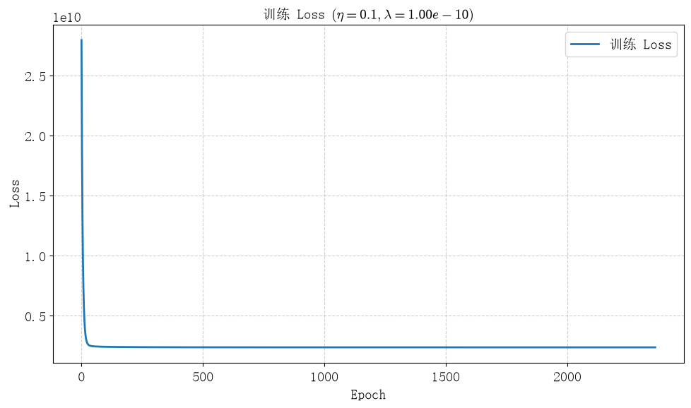

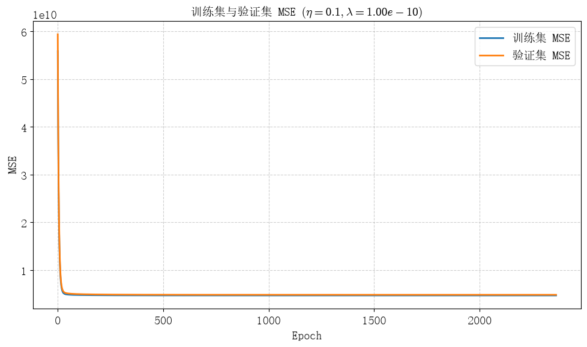

```python
fig_loss, fig_mse = plot_training_history(
    loss_history_final, train_mse_history_final, val_mse_history_final,
    rf" $(\eta={lr_final},\lambda={best_lam_final:.2e})$"
)

display_inline(fig_loss); display_inline(fig_mse)
```

真实价格和预测价格随排名的曲线以及残差随排名的曲线为：

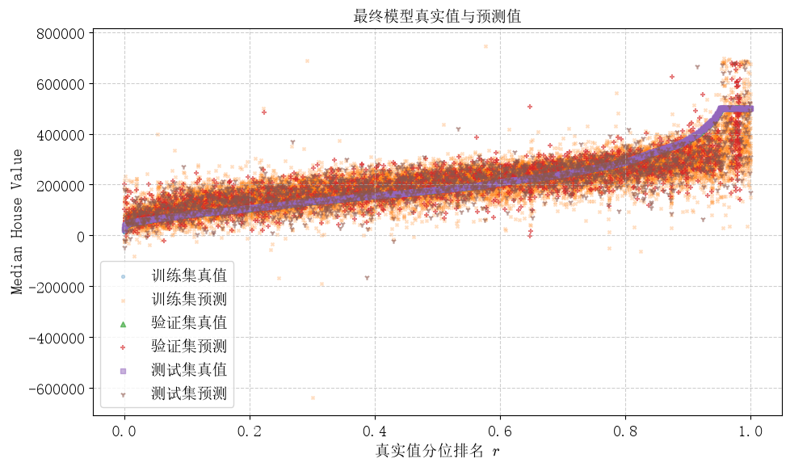

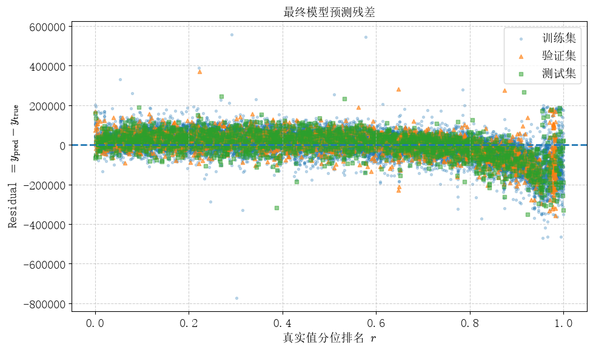

```python
y_true = np.concatenate([y_train, y_val, y_test])
y_pred = np.concatenate([y_train_pred_final, y_val_pred_final, y_test_pred_final])
data_type = np.concatenate([np.zeros(y_train.size), np.ones(y_val.size), np.full(y_test.size, 2)])

idx = np.argsort(y_true); y_true = y_true[idx]; y_pred = y_pred[idx]; data_type = data_type[idx]
residual = y_pred-y_true; rank = np.linspace(0, 1, y_true.size)

train_mask = data_type == 0; val_mask = data_type == 1; test_mask = data_type == 2

fig, ax = plt.subplots(figsize=(10, 6))
ax.scatter(rank[train_mask], y_true[train_mask], marker="o", s=8, alpha=0.25, label="训练集真值")
ax.scatter(rank[train_mask], y_pred[train_mask], marker="x", s=8, alpha=0.25, label="训练集预测")
ax.scatter(rank[val_mask], y_true[val_mask], marker="^", s=20, alpha=0.6, label="验证集真值")
ax.scatter(rank[val_mask], y_pred[val_mask], marker="+", s=20, alpha=0.6, label="验证集预测")
ax.scatter(rank[test_mask], y_true[test_mask], marker="s", s=16, alpha=0.5, label="测试集真值")
ax.scatter(rank[test_mask], y_pred[test_mask], marker="1", s=22, alpha=0.6, label="测试集预测")
ax.set_title("最终模型真实值与预测值"); ax.set_xlabel(r"真实值分位排名 $r$"); ax.set_ylabel("Median House Value")
ax.grid(True, linestyle="--", alpha=0.6); ax.legend(); display_inline(fig)

fig, ax = plt.subplots(figsize=(10, 6))
ax.scatter(rank[train_mask], residual[train_mask], marker="o", s=8, alpha=0.25, label="训练集")
ax.scatter(rank[val_mask], residual[val_mask], marker="^", s=20, alpha=0.6, label="验证集")
ax.scatter(rank[test_mask], residual[test_mask], marker="s", s=16, alpha=0.5, label="测试集")
ax.axhline(0, linestyle="--", linewidth=2)
ax.set_title("最终模型预测残差"); ax.set_xlabel(r"真实值分位排名 $r$"); ax.set_ylabel(r"Residual $=y_{\mathrm{pred}}-y_{\mathrm{true}}$")
ax.grid(True, linestyle="--", alpha=0.6); ax.legend(); display_inline(fig)
```

## 权重分析

线性回归模型不仅可以用于预测, 还可以通过模型参数分析不同输入特征与房价之间的关系.

某一个特征 $x_i$ 对应的权重绝对值 $|w_j|$ 越大, 表示该变量变化一个标准差时引起的预测房价变化越大, 因而在当前线性模型中的影响越明显. 权重为正表示该变量增大时预测房价倾向于增加, 权重为负则表示预测房价倾向于降低.

```python
weight_df = pd.DataFrame({
    "特征": feature_names,
    "标准化权重": w_final[1:],
    "绝对权重": np.abs(w_final[1:])
}).sort_values("绝对权重", ascending=False)

display(weight_df)
```

|  | 特征 | 标准化权重 | 绝对权重 |
| --- | --- | --- | --- |
| 7 | median_income | 75506.314756 | 75506.314756 |
| 1 | latitude | -52882.072030 | 52882.072030 |
| 0 | longitude | -52367.578247 | 52367.578247 |
| 5 | population | -43331.134354 | 43331.134354 |
| 6 | households | 31415.143230 | 31415.143230 |
| 9 | ocean_proximity_<1H OCEAN | 19070.743967 | 19070.743967 |
| 4 | total_bedrooms | 15657.053447 | 15657.053447 |
| 12 | ocean_proximity_NEAR OCEAN | 14195.805694 | 14195.805694 |
| 2 | housing_median_age | 13579.790746 | 13579.790746 |
| 11 | ocean_proximity_NEAR BAY | 10926.312330 | 10926.312330 |
| 8 | bedrooms_per_room | 7449.832559 | 7449.832559 |
| 10 | ocean_proximity_ISLAND | 2068.931747 | 2068.931747 |
| 3 | total_rooms | 1446.460125 | 1446.460125 |

从标准化权重来看, `median_income` 的权重最大, 为约 $7.55\times10^4$. 说明在当前线性模型中, 收入水平与预测房价之间具有最明显的正相关关系. 在控制其他变量不变时, `median_income` 增加一个标准差, 模型预测房价整体上升.

地理位置变量 `latitude` 和 `longitude` 的权重分别约为 $-5.29\times10^4$ 和 $-5.24\times10^4$, 绝对值仅次于 `median_income`. 说明房价具有明显的空间分布特征, 经纬度变化会对模型预测产生较大影响. 但这里的正负号只表示当前坐标方向下的线性变化趋势, 不能简单理解为"越向北"或"越向东"房价一定越低, 因为真实地理分布并不是单一的一维线性关系.

在人口和住房规模变量中, `population` 的权重约为 $-4.33\times10^4$, 是影响较大的负向变量, 而 `households` 的权重约为 $3.14\times10^4$. `total_bedrooms` 为约 $1.57\times10^4$, 而 `total_rooms` 的权重只有约 $1.45\times10^3$. 这些总量变量之间本身存在较强相关性, 因此单个系数反映的是在其他变量同时进入模型后的条件关系, 不应该将其直接解释为独立的因果影响.

对于 `ocean_proximity`, 最终模型已经删除 `INLAND` 并将其作为基准组. 剩余 4 个类别对应的标准化权重均为正, 分别约为

$$ w_{\mathrm{<1H\ OCEAN}}=1.91\times10^4, $$

$$ w_{\mathrm{NEAR\ OCEAN}}=1.42\times10^4, $$

$$ w_{\mathrm{NEAR\ BAY}}=1.09\times10^4, $$

$$ w_{\mathrm{ISLAND}}=2.07\times10^3. $$

这说明在控制收入、位置、人口和住房结构等其他变量后, 这些类别相对于 `INLAND` 基准类别整体表现为正向贡献. 其中 `<1H OCEAN` 的影响最明显, `NEAR OCEAN` 和 `NEAR BAY` 次之, `ISLAND` 的权重相对较小.

人工构造的 `bedrooms_per_room` 权重约为 $7.45\times10^3$. 虽然其绝对权重不是最大的, 但前面的人工特征实验表明, 加入该特征后验证集和测试集 MSE 均得到降低. 说明卧室占总房间数的比例能够补充原始总量变量中没有直接表示的住房结构信息.

综合来看, 当前模型中影响较明显的变量主要集中在收入水平、地理位置和人口规模. 其中 `median_income` 的正向作用最明显, `latitude`、`longitude` 和 `population` 具有较大的负向权重. `ocean_proximity` 在去除 `INLAND` 基准组后仍然表现出较明显的贡献, 说明海岸位置类别中确实包含了房价预测所需要的信息.

## 结论

- 分析了数据预处理对模型结果的影响. 对 `total_bedrooms` 分别采用直接丢弃、中位数填补和平均值填补. 三种方法的 MSE 差异较小, 说明少量缺失值并不是当前模型误差的主要来源. 其中中位数填补的验证集误差最低, 同时对长尾分布中的异常值更加稳健, 因此最终采用训练集的中位数进行填补.
- 分析了文本特征 `ocean_proximity` 的编码方式. 分别比较完整 Onehot 编码、去除一组后的 Onehot 编码、离海岸相关编码和完全不使用文本特征. 结果表明两种 Onehot 编码的 MSE 最低且结果几乎一致, 离海岸相关编码次之, 完全删除文本特征时误差最大. 说明 `ocean_proximity` 包含有效的房价预测信息, 且不同类别之间的差异不能简单表示为单一的离海岸远近关系. 同时完整 Onehot 与常数项之间存在严格线性相关, 因此最终采用去除 `INLAND` 基准组后的 Onehot 编码.
- 分析了人工构造特征对模型性能的影响. 分别加入 `rooms_per_household`、`bedrooms_per_household`、`bedrooms_per_room` 和 `population_per_room`, 并与原始模型和组合人工特征进行比较. 其中 `rooms_per_household` 和 `bedrooms_per_household` 单独加入后验证集误差反而增大, `population_per_room` 对结果影响较小. `bedrooms_per_room` 的改善最明显, 将验证集 MSE 从约 $4.8526\times10^9$ 降低到约 $4.8137\times10^9$, 因此最终只保留 `bedrooms_per_room` 作为人工特征.
- 研究了梯度下降中的学习率、L2 正则化和 Early Stop. 学习率过小时收敛速度较慢, 过大时可能产生振荡, 最终取 $\eta=0.1$. 使用验证集 MSE 进行 Early Stop, 自动确定训练轮数. 扫描不同 L2 系数后发现最优结果出现在接近 $0$ 的区域, 最终最优参数约为 $\lambda=10^{-10}$, 说明当前模型没有明显的高方差问题.
- 对最终模型的标准化权重进行了分析. `median_income` 是绝对权重最大的变量, 说明收入水平是当前模型中与房价关系最明显的因素. `latitude` 和 `longitude` 的绝对权重同样较大, 表明房价具有明显的空间分布特征. `population` 也具有较大的负向权重, 而 `households` 表现为较明显的正向权重. 因此当前模型中影响房价预测最明显的因素主要集中在收入水平、地理位置和人口规模.
- 对 `ocean_proximity` 的最终权重进行分析可以看到, 删除 `INLAND` 并将其作为基准组后, `<1H OCEAN`、`NEAR OCEAN`、`NEAR BAY` 和 `ISLAND` 对应的权重均为正. 说明在控制收入、地理位置、人口规模和住房结构等其他变量后, 这些类别相对于 `INLAND` 整体仍对应更高的预测房价. 这进一步说明海岸位置类别中包含了原始数值变量不能完全替代的有效信息.
- 人工构造特征 `bedrooms_per_room` 的标准化权重约为 $7.45\times10^3$. 虽然其绝对权重并不是最大的, 但加入该特征后验证集和测试集 MSE 均明显下降. 说明该特征的主要作用不是替代已有的重要变量, 而是补充原始总量特征中没有直接表示的住房内部结构信息.

在本次实验所取的一阶线性模型中, 最终采用的处理方法为

$$ \text{中位数填补} + \text{去除一组的 Onehot} + \text{bedrooms\_per\_room} + \text{标准化} + L2 + \text{Early Stop}. $$

最终模型性能约为

$$ \mathrm{MSE}_{\mathrm{train}}=4.6806\times10^9,\qquad R^2_{\mathrm{train}}\approx0.648, $$

$$ \mathrm{MSE}_{\mathrm{val}}=4.8137\times10^9,\qquad R^2_{\mathrm{val}}\approx0.661, $$

$$ \mathrm{MSE}_{\mathrm{test}}=4.6564\times10^9,\qquad R^2_{\mathrm{test}}\approx0.631. $$

但最终 $R^2$ 仍只有约 $0.63\sim0.66$, 且残差分析中仍表现出明显的向均值回归现象, 即低房价区域存在一定高估, 高房价区域存在系统性低估. 这说明当前模型的主要限制已经不是简单的数据预处理问题, 而是一阶线性模型本身的表达能力不足.

## 参考资料以及 AI 使用说明

- 背景补充部分个人写出大体大纲，细节使用 Google Gemini 3.6 Flash 生成并进行人工核验和修改.
- 代码编写使用 Deepseek V4 Flash FIM 模式进行补全和生成（尤其是绘图相关函数，基本是直接生成），经过人工核验和运行验证.
- 扫参函数由 Deepseek V4 Flash 生成，经过人工核验和运行验证，其中核心的每一个参数的训练函数由人工编写.
- 文本和公式编写使用 Deepseek V4 Flash FIM 模式进行生成和补全，经过人工核验和修改.
- 不同数据预处理的预处理代码由 Deepseek V4 Flash 生成，经过人工核验和运行验证.

## 致谢

暂无

## 附一：问题

- 数据集中 `median_house_value` 的高价格区域出现了比较明显的截断现象. 从真实值与预测值的分布中可以看到, 一部分样本集中在相同的最高房价附近, 这可能说明原始数据在采集或发布时对房价设置了上限. 如果目标变量本身存在截断, 那么高房价区域的真实分布就无法被完整观察到, 此时模型在高价格区域出现系统性低估, 不一定完全来自模型表达能力不足, 也可能受到标签截断的影响. 因此可以进一步研究数据集是否对 `median_house_value` 设置了最大值, 以及删除或单独处理这些截断样本后, 模型参数和残差分布是否发生明显变化.
- 人工特征应该如何构造仍然是一个值得进一步研究的问题. 本实验主要根据变量的物理含义和比例关系构造了 `rooms_per_household`、`bedrooms_per_household`、`bedrooms_per_room` 和 `population_per_room` 等特征. 但是人工特征的选择具有一定主观性, 不同组合可能包含不同的信息. 因此一个重要问题是, 如何在保证特征具有实际意义的同时, 系统地搜索有效的组合特征, 并避免构造大量冗余或高度相关的变量.

## 附二：学习心得

暂无